# Genome-resolved metagenomics on anaerobic enrichments from deep subsurface groundwaters

Author

george.westmeijer@umu.se

Published

October 27, 2025

# Document settings

**Expand code**

```r
cite_packages(output = "table", pkgs = "Session", out.dir = getwd())
```

```
    Package Version   Citation
1      base   4.4.2      @base
2 patchwork   1.3.1 @patchwork
3 tidyverse   2.0.0 @tidyverse
```

# Read data and assign colors

All 16S libraries were processed with the bioinformatic pipeline nf-core/ampliseq (v2.12.0), using the SBDI-GTDB (R09-RS220-1) as a reference.

**Expand code**

```r
seqtab <- read_tsv("data/ampliseq/ASV_table.tsv.gz", col_types = cols(.default = col_character(),
                                    count = col_integer()
                                    )) %>%
  group_by(sample) %>% mutate(relab = count / sum(count)) %>% ungroup()

tax <- read_tsv("data/ampliseq/ASV_tax.tsv.gz", col_types = cols(.default = col_character())) %>%
  mutate(phylum = if_else(phylum == "Nanoarchaeota", "Nanobdellota", phylum))

smd <- read_tsv("data/ampliseq/metadata.tsv", col_types = cols(.default = col_character())) %>%
  filter(!sample %in% c("P21015_1082","P21015_1083","P21015_1084","P21015_1087","P21015_1088","P21015_1089"))
```

This project includes 15 metagenomes from 15 unique cultures. The metagenomes contain 35 de-replicated metagenome-assembled genomes (MAG) that are affiliated with the Bacillota (7), Desulfobacterota (7), Pseudomonadota (6), Bacteroidota (4), Patescibacteria (3), Nanobdellota (2), Acidobacteriota (1), Campylobacterota (1), Chloroflexota (1), Iainarchaeota (1), Spirochaetota (1), and Verrucomicrobiota (1).

**Expand code**

```r
coverm <- read_tsv("data/mag/coverm.tsv.gz", col_types = cols(.default = col_character(), tpm = col_double()))

emapper <- read_tsv("data/mag/emapper.tsv.gz", show_col_types = FALSE)

# Sample 35 (l7f) was removed from the binning process as this sample did not produce any bins
bintax <- read_tsv("data/mag/gtdbtk.summary.tsv", col_types = cols(.default = col_character())) %>%
  mutate(phylum = if_else(phylum == "Nanoarchaeota", "Nanobdellota", phylum))

quality <- read_tsv("data/mag/quality_report.tsv", show_col_types = F) %>%
  rename_with(tolower) %>%
  rename(genome = name) %>%
  filter(genome %in% coverm$genome)
```

**Expand code**

```r
cols.gw <- c(
  "KR0015" = "#8D8680",
  "SA1420" = "#A2A475",
  "SA2600" = "#C7B19C"
  )

cols.origin <- c(
  "meteoric" = "#8D8680",
  "marine" = "#A2A475",
  "saline" = "#C7B19C"
  )

cols.fraction <- c(
  "environmental" = "#FAEFD1",
  "fractionated" = "#A2A475",
  "non-fractionated" = "#1B5331"
  )

cols.mag <- c(
  "Other" = "#899DA4",
  "Nanobdellota" = "#046C9A",
  "Patescibacteria" = "#C7B19C",
  "Pseudomonadota" = "#972D15",
  "Desulfobacterota" = "#A2A475",
  "Bacillota" = "#1B5331"
  )

cols.phylum <- c( # Sorted on abundance
  "Patescibacteria" = "#C7B19C",
  "Desulfobacterota" = "#A2A475",
  "Chloroflexota" = "#D69C4E",
  "Atribacterota" = "#972D15",
  "Acidobacteriota" = "#FAEFD1",
  "Omnitrophota" = "#00A08A",
  "Nitrospirota" = "#D8B70A",
  "Campylobacterota" = "#1B5331",
  "Other" = "#899DA4",
  "Unidentified" = "#046C9A"
)
```

# 16S data groundwaters

## Rarefaction 16S data

The 16S data from the groundwater samples are rarefied to check if there is sufficient sequencing depth to estimate microbial diversity.

**Expand code**

```r
t0 <- c(
  "P15009_1057","P15009_1059","P15009_1060","P21015_1020","P21015_1021","P21015_1022", # KR0015
  "P15009_1061","P15009_1065","P15009_1066","P21015_1023","P21015_1024","P21015_1025", # SA1420
  "P15009_1069","P15009_1062","P15009_1063","P21015_1029","P21015_1030","P21015_1031"  # SA2600
       )

# Perform the subsampling
rare <- seqtab %>%
  # Remove negative control
  filter(sample %in% t0) %>%
  select(-relab) %>%
  pivot_wider(names_from = "seqid", values_from = "count", values_fill = 0) %>%
  column_to_rownames("sample") %>%
  vegan::rarecurve(sample = 10000, step = 100, tidy = TRUE) %>%
  tibble() %>%
  rename_with(tolower)
```

**Expand code**

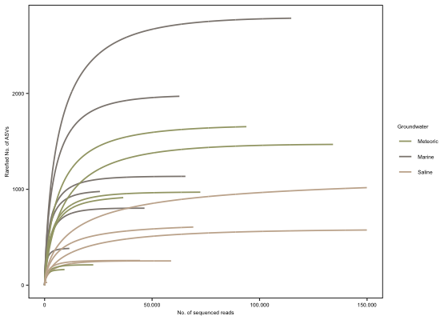

Figure 1: Rarefaction curves for the groundwater samples (t0) for each groundwater type (n = 6).

```r
rare %>%
  inner_join(smd, by = c("site" = "sample")) %>%
  # One sample has ~ 1 million reads
  filter(sample < 150000) %>%
  ggplot(aes(sample, species, group = site, colour = origin)) +
  geom_line(linewidth = 0.75) +
  scale_color_manual(values = cols.origin, name = "Groundwater", labels = c("Meteoric", "Marine", "Saline")) +
  labs(x = "No. of sequenced reads", y = "Rarefied No. of ASVs") +
  scale_x_continuous(labels = c("0", "50.000", "100.000", "150.000")) +
  theme_tidy() +
  theme(
    panel.border = element_rect(fill = "transparent", linewidth = 0.75, colour = "#000000"),

  )
```

**Expand code**

```r
ggsave(filename = "figures/fig-s1.pdf", width = 100, height = 80, units = "mm")
```

## Redundancy analysis

**Expand code**

```r
site <- magick::image_read("figures/äspö-mod.png")

p1 <- ggplot() +
  annotation_custom(grid::rasterGrob(site)) +
  theme_minimal() + coord_fixed() +
  theme(
    plot.margin = margin(),
    aspect.ratio = 0.75
    )
```

As the hydrochemistry data is from a monitoring program, the sampling data closest to groundwater sampling was selected. All units are mg l-1, except for EC (mS m-1), pH, T (degrees C), and O18 (ppt SMOW)

**Expand code**

```r
chem <- read_tsv("data/sicada.txt", show_col_types = FALSE) %>%
  rename_with(tolower) %>%
  filter(sampling) %>%
  select(groundwater = idcode, so4, feii, ph_lab, ec_lab, temp_w, doc, nh4_n, o18, s34_so4) %>%
  inner_join(smd[,c("sample","groundwater")], by = "groundwater")
```

The number of ASVs per sample are estimated with the specnumber() function from the Vegan library.

**Expand code**

```r
adiv <- seqtab %>%
  select(-relab) %>%
  pivot_wider(names_from = "seqid", values_from = "count", values_fill = 0) %>%
  column_to_rownames('sample') %>%
  vegan::specnumber() %>% as.data.frame() %>%
  rownames_to_column('sample') %>% #filter(sample %in% t0) %>%
  rename(specnumber = 2)

chem <- adiv %>% # Add the species richness for each sample
  inner_join(chem, by = "sample")
```

In order to run the RDA, the absolute counts are standardized using a Hellinger transformation (square root of the relative abundance).

**Expand code**

```r
hellinger <- seqtab %>%
  filter(sample %in% t0) %>%
  # Standard Vegan transformation: Turn table with with samples as *rows*
  select(sample, seqid, count) %>%
  pivot_wider(names_from = "seqid", values_from = "count", values_fill = 0) %>%
  # Turn into a numeric matrix
  column_to_rownames('sample') %>% vegan::decostand(method = "hellinger") %>%
  rownames_to_column("sample") %>%
  pivot_longer(-1, names_to = "seqid", values_to = "hellinger")

m <- hellinger %>% # Create a matrix
  spread(seqid, hellinger) %>%
  column_to_rownames("sample")
```

The RDA is called while providing a large number of constraining factors, as the RDA function will by default not include redundant variables (Pearson r > 0.9).

**Expand code**

```r
set.seed(999)

vegan::rda(
  m ~ o18 + doc + ph_lab + ec_lab + temp_w + nh4_n + feii,
  correlation = T,
  data = chem %>%
    semi_join(chem, by = 'sample') %>%
    filter(sample %in% t0) %>%
    arrange(sample) %>%
    column_to_rownames('sample')
) -> rda
```

```
Some constraints or conditions were aliased because they were redundant. This
can happen if terms are constant or linearly dependent (collinear): 'ph_lab',
'ec_lab', 'temp_w', 'nh4_n', 'feii'
```

**Expand code**

```r
# This one will contain the proportions explained which we get by dividing the
# eigenvalue of each component with the sum of eigenvalues for all components.
p <- c(rda$CCA$eig, rda$CA$eig)/sum(c(rda$CCA$eig, rda$CA$eig))
# This one is collecting the coordinates for arrows that will depict how the
# factors in our model point in the coordinate
a <- rda$CCA$biplot %>% data.frame() %>% tibble::rownames_to_column('factor')

lab <- tibble(factor = c("o18", "doc"),
            label = c("delta^18*O", "DOC")
) %>% inner_join(a, by = "factor")

summary(rda)
```

```
Call:
rda(formula = m ~ o18 + doc + ph_lab + ec_lab + temp_w + nh4_n +      feii, data = chem %>% semi_join(chem, by = "sample") %>%      filter(sample %in% t0) %>% arrange(sample) %>% column_to_rownames("sample"),      correlation = T)

Partitioning of variance:
              Inertia Proportion
Total          0.6761     1.0000
Constrained    0.3871     0.5725
Unconstrained  0.2890     0.4275

Eigenvalues, and their contribution to the variance

Importance of components:
                        RDA1   RDA2     PC1     PC2     PC3     PC4     PC5
Eigenvalue            0.2338 0.1533 0.05443 0.04926 0.04333 0.02922 0.02273
Proportion Explained  0.3458 0.2267 0.08051 0.07286 0.06409 0.04322 0.03363
Cumulative Proportion 0.3458 0.5725 0.65305 0.72591 0.79001 0.83323 0.86686
                          PC6     PC7     PC8    PC9     PC10     PC11     PC12
Eigenvalue            0.01598 0.01338 0.01224 0.0098 0.008638 0.007691 0.007139
Proportion Explained  0.02363 0.01979 0.01810 0.0145 0.012776 0.011376 0.010559
Cumulative Proportion 0.89049 0.91028 0.92837 0.9429 0.955646 0.967022 0.977581
                          PC13     PC14     PC15
Eigenvalue            0.006254 0.004717 0.004186
Proportion Explained  0.009250 0.006977 0.006192
Cumulative Proportion 0.986831 0.993808 1.000000

Accumulated constrained eigenvalues
Importance of components:
                        RDA1   RDA2
Eigenvalue            0.2338 0.1533
Proportion Explained  0.6040 0.3960
Cumulative Proportion 0.6040 1.0000
```

**Expand code**

```r
vegan::RsquareAdj(rda)
```

```
$r.squared
[1] 0.5725442

$adj.r.squared
[1] 0.5155501
```

**Expand code**

```r
p2 <- rda$CCA$wa %>% data.frame() %>% tibble::rownames_to_column('sample') %>%
  inner_join(chem, by = 'sample') %>%
  ggplot(aes(x = RDA1, y = RDA2)) +
  geom_vline(xintercept = 0, colour = "grey", linetype = "dotted") +
  geom_hline(yintercept = 0, colour = "grey", linetype = "dotted") +
  geom_point(aes(colour = groundwater, size = specnumber), shape = 1, stroke = 0.5) +
  xlab(sprintf("RDA1 (%2.1f%% explained)", p[[1]] * 100)) +
  ylab(sprintf("RDA2 (%2.1f%% explained)", p[[2]] * 100)) +
  geom_segment(
    data = a, mapping = aes(xend = RDA1/5, yend = RDA2/5), linewidth = 0.3,
    x = 0, y = 0, arrow = arrow(length = unit(1.5, "mm"), type = "closed")
    ) +
  geom_label(
    data = lab, mapping = aes(x = RDA1/10, y = RDA2/10, label = label),
    size = 6/.pt, parse = TRUE, label.size = 0, label.padding = unit(0.1, "lines")
    ) +
  scale_size(range = c(1,8), name = "No. of ASVs") +
  annotate("text", x = -0.07, y =-0.3, label = "Meteoric", colour = cols.gw[1], size = 7/.pt) +
  annotate("text", x = 0.06, y = 0.28, label = "Marine", colour = cols.gw[2], size = 7/.pt) +
  annotate("text", x =  0.2, y = -0.05, label = "Saline", colour = cols.gw[3], size = 7/.pt) +
  stat_ellipse(aes(x = RDA1, y = RDA2, colour = groundwater),
               geom = "polygon", show.legend = F,
               fill = NA, linetype = "dashed") +
  # Add R-squared
  annotate("text", x = Inf, y = -Inf,
           label = "paste(R ^ 2, \" = 0.52\")",
           size = 6/.pt, vjust = -0.5, hjust = 1.05, parse = TRUE) +
  scale_color_manual(name = "",values = cols.gw, guide = "none") +
  scale_fill_manual(name = "",values = cols.gw, guide = "none") +
  theme_tidy(fontsize = 6) +
  theme(
    aspect.ratio = 1.0,
    legend.background = element_rect(fill = NA),
    panel.border = element_rect(fill = "transparent", linewidth = 0.75),
    legend.text = element_text(margin = margin(r = 12, unit = "pt")),
    legend.position = "inside",
    legend.position.inside  = c(0.9,0.85)
    )
```

## Overview community structure t0

To visualize the community composition, the most abundant phyla are identified while grouping less abundant phyla as “Other”. ASVs that are not identified on phylum level are included as “Unidentified”.

**Expand code**

```r
t <- seqtab %>%
  filter(sample %in% t0) %>%
  inner_join(tax, by = "seqid") %>%
  group_by(phylum, sample) %>%
  # Sum the abundance of each phylum within a sample
  summarise(relab = sum(relab), .groups = 'drop_last') %>%
  # Calculate the mean abundance of each phylum over the categories
  summarise(mean_relab = sum(relab), .groups = 'drop') %>%
  filter(!is.na(phylum)) %>%
  top_n(8, mean_relab)

cols.phylum <- c( # Sorted on abundance
  "Patescibacteria" = "#C7B19C",
  "Desulfobacterota" = "#A2A475",
  "Chloroflexota" = "#D69C4E",
  "Atribacterota" = "#972D15",
  "Acidobacteriota" = "#FAEFD1",
  "Omnitrophota" = "#00A08A",
  "Nitrospirota" = "#D8B70A",
  "Campylobacterota" = "#1B5331",
  "Other" = "#899DA4",
  "Unidentified" = "#046C9A"
)

t %>% arrange(desc(mean_relab)) %>% knitr::kable()
```

| phylum | mean_relab |
| --- | --- |
| Patescibacteria | 7.1312325 |
| Desulfobacterota | 2.7429408 |
| Chloroflexota | 1.2292858 |
| Atribacterota | 1.2125307 |
| Acidobacteriota | 0.9182271 |
| Omnitrophota | 0.7237157 |
| Nitrospirota | 0.3144247 |
| Campylobacterota | 0.2617040 |

**Expand code**

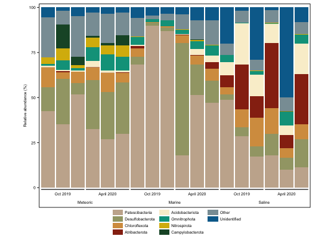

Figure 2: Community composition of the groundwater samples (t0) for each groundwater type (n = 6) before (October 2019) and after (April 2020) collection of groundwater for inoculation. The eight most abundant phyla are shown, grouping less abundant phyla as “Other” and uncharacterized ASVs as “Unidentified”.

```r
t <- t %>% pull(phylum)

p3 <- seqtab %>%
  filter(sample %in% t0) %>%
  inner_join(tax, by = "seqid") %>%
  mutate(phylum = case_when(
    phylum %in% t ~ phylum,
    is.na(phylum) ~ "Unidentified",
    !phylum %in% t ~ "Other"
  )) %>%
  # Summarize in order to have the sum for each category and phylum
  group_by(sample, phylum) %>%
  summarise(mrelab = sum(relab), .groups = 'drop') %>%
  # Call the plot
  ggplot(aes(x = fct_relevel(sample, t0),
             y = mrelab * 100,
             fill = fct_relevel(phylum, names(cols.phylum) %>% rev())
             )
         ) +
  labs(x = '', y = 'Relative abundance (%)', fill = "") +
  geom_col() + scale_y_continuous(expand = c(0.01,0), limits = c(-10,101)) +
  annotate(geom = "segment", x =  0.55, xend =  3.45, y = -1, yend = -1, linewidth = 0.5) +
  annotate(geom = "segment", x =  3.55, xend =  6.45, y = -1, yend = -1, linewidth = 0.5) +
  annotate(geom = "segment", x =  6.55, xend =  9.45, y = -1, yend = -1, linewidth = 0.5) +
  annotate(geom = "segment", x =  9.55, xend = 12.45, y = -1, yend = -1, linewidth = 0.5) +
  annotate(geom = "segment", x = 12.55, xend = 15.45, y = -1, yend = -1, linewidth = 0.5) +
  annotate(geom = "segment", x = 15.55, xend = 18.45, y = -1, yend = -1, linewidth = 0.5) +
  # Labels dates
  annotate(geom = "text", x =  2, y = -3.5, label = "Oct 2019", size = 6/.pt) +
  annotate(geom = "text", x =  5, y = -3.5, label = "April 2020", size = 6/.pt) +
  annotate(geom = "text", x =  8, y = -3.5, label = "Oct 2019", size = 6/.pt) +
  annotate(geom = "text", x = 11, y = -3.5, label = "April 2020", size = 6/.pt) +
  annotate(geom = "text", x = 14, y = -3.5, label = "Oct 2019", size = 6/.pt) +
  annotate(geom = "text", x = 17, y = -3.5, label = "April 2020", size = 6/.pt) +
  # Labels groundwater
  annotate(geom = "text", x = 3.5, y = -8, label = "Meteoric", size = 6/.pt) +
  annotate(geom = "text", x = 9.5, y = -8, label = "Marine", size = 6/.pt) +
  annotate(geom = "text", x =15.5, y = -8, label = "Saline", size = 6/.pt) +
  scale_fill_manual(values = cols.phylum) +
  guides(fill = guide_legend(ncol = 3, reverse = TRUE)) +
  theme_tidy(legend = "bottom", fontsize = 6) +
  theme(
    aspect.ratio = 0.75,
    axis.text.x = element_blank(),
    axis.ticks.x = element_blank(),
    legend.key.height = unit(3.5, "mm"),
    legend.margin = margin(t = -20),
    legend.text = element_text(margin = margin(l = 2)),
    panel.border = element_rect(fill = "transparent", linewidth = 0.75),
    legend.key.spacing.y = unit(0, "mm")
    )

p3
```

## Alpha diversity

**Expand code**

```r
adiv <- seqtab %>%
  select(-relab) %>%
  spread(seqid, count, fill = 0) %>%
  column_to_rownames('sample') %>%
  vegan::diversity() %>% as.data.frame() %>%
  rownames_to_column('sample') %>%
  rename(shannon = 2) %>%
  inner_join(smd, by = "sample")

adiv %>% filter(sample %in% t0) %>%
  group_by(groundwater) %>%
  summarise(mean = round(mean(shannon), digits = 2), sd = round(sd(shannon), digits = 2), n = n())
```

```
# A tibble: 3 × 4
  groundwater  mean    sd     n
  <chr>       <dbl> <dbl> <int>
1 KR0015       5.66  0.62     6
2 SA1420       3.27  1.07     6
3 SA2600       3.03  0.44     6
```

**Expand code**

```r
p4 <- adiv %>%
  filter(origin != "control") %>%
  mutate(fraction = factor(fraction, levels = c("environmental","fractionated","non-fractionated"))) %>%
  ggplot(aes(
    x = groundwater,
    y = shannon,
    fill = fraction
    )) +
  geom_boxplot(outlier.colour = "white") +
  geom_point(position = position_jitterdodge(
    jitter.width = 0.1, dodge.width = 0.7),
    size = 1.5, shape = 21, stroke = 0.5, key_glyph = "boxplot") +
  labs(x = "", y = "Shannon's diversity index (H)", fill = "") +
  theme_tidy(legend = "inside", fontsize = 6) +
  scale_x_discrete(labels = c("Meteoric", "Marine", "Saline")) +
  scale_fill_manual(values = cols.fraction, labels = c("Environmental", "< 0.45 µm", "Non-fractionated")) +
  theme(
    aspect.ratio = 1.0,
    panel.border = element_rect(fill = "transparent", linewidth = 0.75),
    legend.margin = margin(),
    legend.background = element_rect(fill = "NA"),
    legend.position.inside = c(0.8,0.88),
    legend.text = element_text(margin = margin(l = 1))
  )
```

**Expand code**

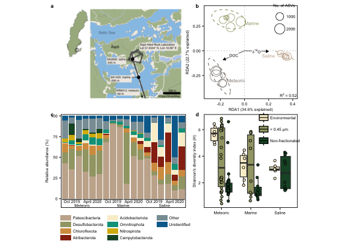

```r
p1 + p2 + p3 + p4 + plot_layout(nrow = 2) + plot_annotation(tag_levels = "a") &
  theme(
    plot.margin = margin(t = 4, r = .1),
    plot.tag.location = "panel",
    plot.tag.position = c(-0.07, 1.0),
    plot.tag = element_text(size = 8, face = "bold")
    )
```

**Expand code**

```r
ggsave("figures/fig-1.pdf", width = 180, height = 180, units = "mm")
```

## Community structure on abundant groups (not tied to a specific rank)

**Expand code**

```r
t <- tax %>%
  mutate(rank = case_when(
    class == "ABY1" ~ "ABY1",
    class == "Paceibacteria" ~ "Paceibacteria",
    class == "Microgenomatia" ~ "Microgenomatia",
    class == "JS1" ~ "JS1",
    order == "Syntrophales" ~ "Syntrophales",
    order == "Desulfobulbales" ~ "Desulfobulbales",
    order == "Anaerolineales" ~ "Anaerolineales",
    order == "Thermodesulfovibrionales" ~ "Thermodesulfovibrionales",
    order == "Gygaellales" ~ "Gygaellales",
    genus == "Sulfuricurvum" ~ "Sulfuricurvum",
    .default = NA
  )) %>% filter(!is.na(rank))

cols.rank <- c( # Sorted on abundance
  "ABY1" = "#C7B19C",
  "Paceibacteria" = "#A2A475",
  "Microgenomatia" = "#D69C4E",
  "JS1" = "#972D15",
  "Syntrophales" = "#FAEFD1",
  "Desulfobulbales" = "#00A08A",
  "Anaerolineales" = "#D8B70A",
  "Thermodesulfovibrionales" = "#1B5331",
  "Gygaellales" = "#899DA4",
  "Sulfuricurvum" = "#046C9A"
)
```

**Expand code**

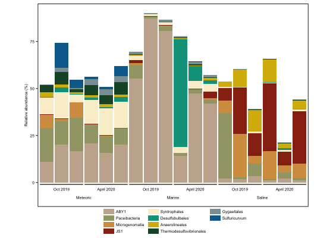

```r
seqtab %>%
  filter(sample %in% t0) %>%
  inner_join(t, by = "seqid") %>%
  group_by(sample, rank) %>%
  summarise(mrelab = sum(relab), .groups = 'drop') %>%
  # Call the plot
  ggplot(aes(x = fct_relevel(sample, t0),
             y = mrelab * 100,
             fill = fct_relevel(rank, names(cols.rank) %>% rev())
             )
         ) +
  labs(x = '', y = 'Relative abundance (%)', fill = "") +
  geom_col() +
  annotate(geom = "segment", x =  0.55, xend =  3.45, y = -1, yend = -1, linewidth = 0.5) +
  annotate(geom = "segment", x =  3.55, xend =  6.45, y = -1, yend = -1, linewidth = 0.5) +
  annotate(geom = "segment", x =  6.55, xend =  9.45, y = -1, yend = -1, linewidth = 0.5) +
  annotate(geom = "segment", x =  9.55, xend = 12.45, y = -1, yend = -1, linewidth = 0.5) +
  annotate(geom = "segment", x = 12.55, xend = 15.45, y = -1, yend = -1, linewidth = 0.5) +
  annotate(geom = "segment", x = 15.55, xend = 18.45, y = -1, yend = -1, linewidth = 0.5) +
  # Labels dates
  annotate(geom = "text", x =  2, y = -3.5, label = "Oct 2019", size = 6/.pt) +
  annotate(geom = "text", x =  5, y = -3.5, label = "April 2020", size = 6/.pt) +
  annotate(geom = "text", x =  8, y = -3.5, label = "Oct 2019", size = 6/.pt) +
  annotate(geom = "text", x = 11, y = -3.5, label = "April 2020", size = 6/.pt) +
  annotate(geom = "text", x = 14, y = -3.5, label = "Oct 2019", size = 6/.pt) +
  annotate(geom = "text", x = 17, y = -3.5, label = "April 2020", size = 6/.pt) +
  # Labels groundwater
  annotate(geom = "text", x = 3.5, y = -8, label = "Meteoric", size = 6/.pt) +
  annotate(geom = "text", x = 9.5, y = -8, label = "Marine", size = 6/.pt) +
  annotate(geom = "text", x =15.5, y = -8, label = "Saline", size = 6/.pt) +
  scale_fill_manual(values = cols.rank) +
  guides(fill = guide_legend(ncol = 3, reverse = TRUE)) +
  theme_tidy(legend = "bottom", fontsize = 6) +
  theme(
    aspect.ratio = 0.75,
    axis.text.x = element_blank(),
    axis.ticks.x = element_blank(),
    legend.key.height = unit(3.5, "mm"),
    legend.margin = margin(t = -20),
    legend.text = element_text(margin = margin(l = 2)),
    panel.border = element_rect(fill = "transparent", linewidth = 0.75),
    legend.key.spacing.y = unit(0, "mm")
    )
```

**Expand code**

```r
ggsave(filename = "figures/fig-s2.pdf", width = 120, height = 90, units = "mm")
```

## Network analysis: phylum

**Expand code**

```r
t <- c(
  "Spirochaetota", "Acidobacteriota", "Atribacterota", "Chloroflexota",
  "Omnitrophota", "Nanobdellota", "Campylobacterota", "Pseudomonadota"
)

# This object is the amplicon data grouped by phylum from https://doi.org/10.3389/fmicb.2018.02880
network.survey <- read_tsv("data/ampliseq/network-survey.tsv", show_col_types = F)

# Correlation between the abundance of the phyla using the cultures
fit <- tibble("phylum" = t, "r.squared" = NA)
for (i in t) {
  model <- lm(relab ~ cpr, data = network.survey %>% filter(phylum == i)) %>% summary()
  fit[fit$phylum == i, "r.squared"] <- model$adj.r.squared %>% round(digits = 2)
}

fit
```

```
# A tibble: 8 × 2
  phylum           r.squared
  <chr>                <dbl>
1 Spirochaetota         0.57
2 Acidobacteriota       0.55
3 Atribacterota         0.51
4 Chloroflexota         0.14
5 Omnitrophota          0.14
6 Nanobdellota          0.08
7 Campylobacterota      0.05
8 Pseudomonadota       -0.01
```

**Expand code**

```r
p1 <- network.survey %>%
  mutate(phylum = factor(phylum, levels = fit$phylum)) %>%
  ggplot(aes(
    x = sqrt(cpr * 100),
    y = sqrt(relab * 100)
  )) +
  geom_point(shape = 21, stroke = 0.75, fill = "white") +
  geom_label(data = fit %>% mutate(phylum = factor(phylum, levels = phylum)),
            aes(x = Inf, y = -Inf, label = paste("R^{2}:", r.squared)),
            size = 5/.pt, hjust = 1, vjust = 0, parse = TRUE, label.size = 0, fill = "white") +
  geom_smooth(method = "lm", formula = y ~ x, colour = "black", fill = "#D9D9D9", linewidth = 0.5) +
  labs(x = "Sqrt relative abundance Patescibacteria (%)", y = "Sqrt relative abundance (%)") +
  theme_tidy(fontsize = 5) +
  scale_y_continuous(labels = function(x) sprintf("%.1f", x)) +
  facet_wrap(~phylum, scales = "free", ncol = 4) +
  theme(
    strip.background = element_rect(fill = "#F0F0F0")
  )
```

**Expand code**

```r
t <- c(
  "Omnitrophota", "Chloroflexota", "Pseudomonadota", "Actinomycetota",
  "Verrucomicrobiota", "Acidobacteriota", "Bacillota", "Spirochaetota"
)

network <- seqtab %>%
  inner_join(smd, by = "sample") %>%
  filter(fraction == "non-fractionated") %>%
  inner_join(tax, by = "seqid") %>% filter(phylum %in% t) %>%
  group_by(sample, phylum) %>% summarise(relab = sum(relab), .groups = "drop")

network <- seqtab %>%
  inner_join(tax, by = "seqid") %>% filter(phylum == "Patescibacteria") %>%
  group_by(sample, phylum) %>% summarise(cpr = sum(relab), .groups = "drop") %>% select(-phylum) %>%
  inner_join(network, by = "sample")

# Correlation between the abundance of the phyla using the cultures
fit <- tibble("phylum" = t, "r.squared" = NA)
for (i in t) {
  model <- lm(relab ~ cpr, data = network %>% filter(phylum == i)) %>% summary()
  fit[fit$phylum == i, "r.squared"] <- model$adj.r.squared %>% round(digits = 2)
}

fit <- fit %>% arrange(desc(r.squared))
fit
```

```
# A tibble: 8 × 2
  phylum            r.squared
  <chr>                 <dbl>
1 Omnitrophota           0.81
2 Chloroflexota          0.6
3 Actinomycetota         0.03
4 Pseudomonadota         0.02
5 Bacillota             -0.01
6 Verrucomicrobiota     -0.02
7 Acidobacteriota       -0.02
8 Spirochaetota         -0.02
```

**Expand code**

```r
n <- network %>%
  group_by(phylum) %>% summarise(no = n(), .groups = "drop") %>%
  inner_join(fit, by = "phylum") %>% mutate(no = as.character(no)) %>%
  mutate(phylum = factor(phylum, levels = fit$phylum)) %>%
  arrange(phylum)

p2 <- network %>%
  mutate(phylum = factor(phylum, levels = fit$phylum)) %>%
  ggplot(aes(
    x = sqrt(cpr * 100),
    y = sqrt(relab * 100)
  )) +
  geom_point(shape = 21, stroke = 0.75, fill = "white") +
  geom_label(data = n,
            aes(x = Inf, y = -Inf, label = paste("R^{2}: ", r.squared, " (", no, ")", sep = "")),
            size = 5/.pt, hjust = 1.0, vjust = -0.0, parse = TRUE, label.size = 0, fill = "white") +
  geom_smooth(method = "lm", formula = y ~ x, colour = "black", fill = "#D9D9D9", linewidth = 0.5) +
  labs(x = "Sqrt relative abundance Patescibacteria (%)", y = "Sqrt relative abundance (%)") +
  theme_tidy(fontsize = 5) +
  scale_y_continuous(labels = function(x) sprintf("%.1f", x)) +
  facet_wrap(~phylum, scales = "free", ncol = 4) +
  theme(
    strip.background = element_rect(fill = "#F0F0F0")
  )
```

**Expand code**

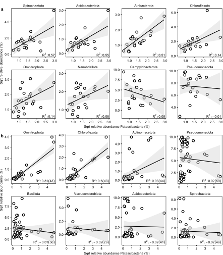

Figure 3

```r
p1 / p2 + plot_annotation(tag_levels = c("a", "b")) & theme(
  panel.border = element_rect(fill = "transparent", linewidth = 0.5),
  axis.ticks.length = unit(0.5, "mm"),
  plot.margin = margin(t = 4, r = 1),
  plot.tag = element_text(),
  plot.tag.position = c(0.01, 0.96),
  strip.background = element_blank(),
  strip.text = element_text(margin = margin(b = 2))
)
```

**Expand code**

```r
ggsave("figures/fig-s5.pdf", width = 160, height = 160, units = "mm")
```

## Network analysis: order

**Expand code**

```r
t <- c(
  "Spirochaetota", "Acidobacteriota", "Atribacterota", "Chloroflexota",
  "Omnitrophota", "Nanobdellota", "Campylobacterota", "Pseudomonadota"
)

# The file survey-amplicons.tsv contains the ASVs from Äspö groundwaters published in https://doi.org/10.3389/fmicb.2018.02880
survey.amplicons <- read_tsv("data/ampliseq/survey-amplicons.tsv.gz", show_col_types = FALSE) %>%
  group_by(sample) %>% mutate(relab = count / sum(count)) %>% ungroup()

cpr <- survey.amplicons %>%
  filter(phylum == "Patescibacteria") %>%
  group_by(sample, order) %>% summarise(cpr = sum(relab), .groups = "drop")

network.survey <- survey.amplicons %>%
  filter(phylum %in% t) %>%
  group_by(sample, order) %>% summarise(relab = sum(relab), .groups = "drop") %>%
  # Add colum with abundance of CPR
  left_join(cpr, by = "sample", relationship = "many-to-many") %>%
  rename(order.clade = order.x, order.cpr = order.y)

# The filter > 19 implies that the two orders have to co-occur at least ten times
fit <- network.survey %>%
  group_by(order.clade, order.cpr) %>% summarize(n = n(), .groups = "drop_last") %>%
  filter(n > 19) %>% ungroup() %>% na.omit()

for (i in 1:nrow(fit)) {
  data = network.survey %>% filter(order.clade == fit[i,]$order.clade & order.cpr == fit[i,]$order.cpr)
  model <- lm(relab ~ cpr, data = data)
  fit[i, "r.squared"] <- summary(model)$r.squared
}

fit <- fit %>% slice_max(r.squared, n = 8) %>%
  mutate(clade = paste(order.clade, order.cpr)) %>%
  mutate(r.squared = signif(.$r.squared, digits = 2)) %>%
  arrange(desc(r.squared)) %>%
  mutate(n = as.character(n))
```

**Expand code**

```r
label <- c(
  "Limnocylindrales UBA9983" = "Limnocylindrales\n-\nUBA9983",
  "Limnocylindrales UBA12405" = "Limnocylindrales\n-\nUBA12405",
  "Limnocylindrales JAHJFT01" = "Limnocylindrales\n-\nJAHJFT01",
  "Limnocylindrales JAHISW01" = "Limnocylindrales\n-\nJAHISW01",
  "UBA2200 JAHJFT01" = "UBA2200\n-\nJAHJFT01",
  "Limnocylindrales UBA1369" = "Limnocylindrales\n-\nUBA1369",
  "Limnocylindrales Paceibacterales" = "Limnocylindrales\n-\nPaceibacterales",
  "Limnocylindrales UBA1558" = "Limnocylindrales\n-\nUBA1558"
  )

p1 <- network.survey %>%
  mutate(clade = paste(order.clade, order.cpr)) %>%
  filter(clade %in% fit$clade) %>%
  mutate(clade = factor(clade, levels = fit$clade)) %>%
  ggplot(aes(
    x = sqrt(cpr * 100),
    y = sqrt(relab * 100)
  )) +
  geom_point(shape = 21, stroke = 0.75, fill = "white") +
  geom_label(data = fit %>% mutate(clade = factor(clade, levels = clade)),
            aes(x = Inf, y = -Inf, label = paste("R^{2}: ", r.squared, " (", n, ")", sep = "")),
            size = 5/.pt, hjust = 1.0, vjust = -0.0, parse = TRUE, label.size = 0, fill = "white") +
  geom_smooth(method = "lm", formula = y ~ x, colour = "black", fill = "#D9D9D9", linewidth = 0.5) +
  labs(x = "Sqrt relative abundance Patescibacteria (%)", y = "Sqrt relative abundance (%)") +
  theme_tidy(fontsize = 5) +
  scale_y_continuous(labels = function(x) sprintf("%.1f", x)) +
  facet_wrap(~clade, scales = "free", ncol = 4, labeller = as_labeller(label)) +
  theme(
    strip.background = element_rect(fill = "#F0F0F0")
  )
```

**Expand code**

```r
t <- c(
  "Omnitrophota", "Chloroflexota", "Pseudomonadota", "Actinobacteriota",
  "Verrucomicrobiota", "Acidobacteriota", "Bacillota", "Spirochaetota"
)

cpr <- seqtab %>%
  inner_join(smd, by = "sample") %>%
  filter(fraction == "non-fractionated") %>%
  inner_join(tax, by = "seqid") %>% filter(phylum == "Patescibacteria") %>%
  group_by(sample, order) %>% summarise(cpr = sum(relab), .groups = "drop")

network <- seqtab %>%
  inner_join(smd, by = "sample") %>%
  filter(fraction == "non-fractionated") %>%
  inner_join(tax, by = "seqid") %>% filter(phylum %in% t) %>%
  group_by(sample, order) %>% summarise(relab = sum(relab), .groups = "drop") %>%
  # Add colum with abundance of CPR
  left_join(cpr, by = "sample", relationship = "many-to-many") %>%
  rename(order.clade = order.x, order.cpr = order.y)

# The filter > 19 implies that the two orders have to co-occur at least ten times
fit <- network %>%
  group_by(order.clade, order.cpr) %>% summarize(n = n(), .groups = "drop_last") %>%
  filter(n > 19) %>% ungroup() %>% na.omit()

for (i in 1:nrow(fit)) {
  data = network %>% filter(order.clade == fit[i,]$order.clade & order.cpr == fit[i,]$order.cpr)
  model <- lm(relab ~ cpr, data = data)
  fit[i, "r.squared"] <- summary(model)$adj.r.squared
}
fit <- fit %>% slice_max(r.squared, n = 8) %>%
  mutate(clade = paste(order.clade, order.cpr)) %>%
  mutate(r.squared = signif(.$r.squared, digits = 2)) %>%
  arrange(desc(r.squared)) %>%
  mutate(n = as.character(n))
```

**Expand code**

```r
label = c(
  "2-01-FULL-45-10 BM507" = "2-01-FULL-45-10\n-\nBM507",
  "Gygaellales BM507" = "Gygaellales\n-\nBM507",
  "Gorgyraeales BM507" = "Gorgyraeales\n-\nBM507",
  "Pluralincolimonadales Portnoybacterales" = "Pluralincolimonadales\n-\nPortnoybacterales",
  "Gygaellales Magasanikbacterales" = "Gygaellales\n-\nMagasanikbacterales",
  "Pluralincolimonadales BM507" = "Pluralincolimonadales\n-\nBM507",
  "Gygaellales Portnoybacterales" = "Gygaellales\n-\nPortnoybacterales",
  "Gygaellales SG8-24" = "Gygaellales\n-\nSG8-24"
)


p2 <- network %>%
  mutate(clade = paste(order.clade, order.cpr)) %>%
  filter(clade %in% fit$clade) %>%
  mutate(clade = factor(clade, levels = fit$clade)) %>%
  ggplot(aes(
    x = sqrt(cpr * 100),
    y = sqrt(relab * 100)
  )) +
  geom_point(shape = 21, stroke = 0.75, fill = "white") +
  geom_label(data = fit %>% mutate(clade = factor(clade, levels = clade)),
            aes(x = Inf, y = -Inf, label = paste("R^{2}: ", r.squared, " (", n, ")", sep = "")),
            size = 5/.pt, hjust = 1.0, vjust = -0.0, parse = TRUE, label.size = 0, fill = "white") +
  geom_smooth(method = "lm", formula = y ~ x, colour = "black", fill = "#D9D9D9", linewidth = 0.5) +
  labs(x = "", y = "Sqrt relative abundance (%)") +
  theme_tidy(fontsize = 5) +
  scale_y_continuous(labels = function(x) sprintf("%.1f", x)) +
  facet_wrap(~clade, scales = "free", ncol = 4, labeller = as_labeller(label)) +
  theme(
    strip.background = element_rect(fill = "#F0F0F0")
  )
```

**Expand code**

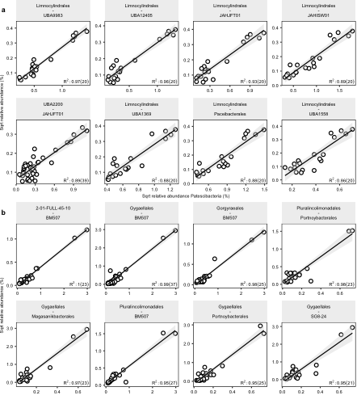

```r
p1 / p2 +
  plot_annotation(tag_levels = c("a", "b")) & theme(
  panel.border = element_rect(fill = "transparent", linewidth = 0.5),
  axis.ticks.length = unit(0.5, "mm"),
  plot.margin = margin(b = 4, r = 1),
  plot.tag.position = c(0.01, 0.95)
)
```

**Expand code**

```r
ggsave("figures/fig-s6.pdf", width = 140, height = 160, units = "mm")
```

# Negative controls

## Negative controls: phylum

**Expand code**

```r
t <- seqtab %>%
  filter(sample %in% c("P21015_1085", "P21015_1086", "P21015_1090", "P21015_1091", "P21015_1032", "P21015_1033")) %>%
  inner_join(tax, by = "seqid") %>%
  group_by(phylum, sample) %>%
  # Sum the abundance of each phylum within a sample
  summarise(relab = sum(relab), .groups = 'drop_last') %>%
  # Calculate the mean abundance of each phylum over the categories
  summarise(mean_relab = sum(relab), .groups = 'drop') %>%
  filter(!is.na(phylum)) %>%
  top_n(8, mean_relab)

cols.phylum <- c(
  "Pseudomonadota" = "#972D15",
  "Acidobacteriota" = "#FAEFD1",
  "Actinomycetota" = "#C6CDF7",
  "Spirochaetota" = "#D8B70A",
  "Cyanobacteriota" = "#046C9A",
  "Desulfobacterota" = "#A2A475",
  "Bacillota" = "#1B5331",
  "Patescibacteria" = "#C7B19C",
  "Other" = "#899DA4"
)
```

**Expand code**

```r
p.phylum <- seqtab %>%
  filter(sample %in% c("P21015_1085", "P21015_1086", "P21015_1090", "P21015_1091", "P21015_1032", "P21015_1033")) %>%
  inner_join(tax, by = "seqid") %>%
  mutate(phylum = case_when(
    phylum %in% t$phylum ~ phylum,
    is.na(phylum) ~ "Other",
    !phylum %in% t$phylum ~ "Other"
  )) %>%
  # Summarize in order to have the sum for each category and topphylum
  group_by(sample, phylum) %>%
  summarise(relab = sum(relab), .groups = 'drop') %>%
  # Call the plot
  ggplot(aes(x = sample,
             y = relab * 100,
             fill = fct_relevel(phylum, names(cols.phylum) %>% rev())
             )
         ) +
  labs(x = '', y = 'Relative abundance (%)', fill = "") +
  geom_col() + scale_y_continuous(expand = c(0.01,0), limits = c(-6,101)) +
  annotate(geom = "segment", x =  0.55, xend =  2.45, y = -1, yend = -1, linewidth = 0.5) +
  annotate(geom = "segment", x =  2.55, xend =  4.45, y = -1, yend = -1, linewidth = 0.5) +
  annotate(geom = "segment", x =  4.55, xend =  6.45, y = -1, yend = -1, linewidth = 0.5) +
  # Label controls
  annotate(geom = "text", x =  1.5, y = -3.5, label = "Extraction controls", size = 5/.pt) +
  annotate(geom = "text", x =  3.5, y = -3.5, label = "Acetate controls", size = 5/.pt) +
  annotate(geom = "text", x =  5.5, y = -3.5, label = "Lysate controls", size = 5/.pt) +
  annotate(geom = "text", x =  1, y = 3.5, label = "376 ASVs", size = 5/.pt) +
  annotate(geom = "text", x =  2, y = 3.5, label = "358", size = 5/.pt) +
  annotate(geom = "text", x =  3, y = 3.5, label = "141", size = 5/.pt) +
  annotate(geom = "text", x =  4, y = 3.5, label = "183", size = 5/.pt) +
  annotate(geom = "text", x =  5, y = 3.5, label = "233", size = 5/.pt) +
  annotate(geom = "text", x =  6, y = 3.5, label = "220", size = 5/.pt) +
  scale_fill_manual(values = cols.phylum) +
  theme_tidy(legend = "bottom", fontsize = 5) +
  guides(fill = guide_legend(nrow = 3, reverse = T)) +
  theme(
    aspect.ratio = 0.75,
    axis.text.x = element_blank(),
    axis.ticks.x = element_blank(),
    legend.key.height = unit(3.5, "mm"),
    legend.margin = margin(t = -10),
    legend.text = element_text(margin = margin(l = 2)),
    panel.border = element_rect(fill = "transparent", linewidth = 0.75),
    legend.key.spacing.y = unit(0, "mm")
    )
```

## Negative controls: order

**Expand code**

```r
c <- c("P21015_1085", "P21015_1086", "P21015_1090", "P21015_1091", "P21015_1032", "P21015_1033")

t <- seqtab %>%
  filter(sample %in% c) %>%
  inner_join(tax, by = "seqid") %>%
  group_by(order, sample) %>%
  # Sum the abundance of each phylum within a sample
  summarise(relab = sum(relab), .groups = 'drop_last') %>%
  # Calculate the mean abundance of each phylum over the categories
  summarise(mean_relab = sum(relab), .groups = 'drop') %>%
  filter(!is.na(order)) %>%
  top_n(8, mean_relab)

cols.order <- c(
  "Burkholderiales" = "#972D15",
  "Holophagales" = "#FAEFD1",
  "Mycobacteriales" = "#C6CDF7",
  "Treponematales" = "#D8B70A",
  "PCC-6307" = "#046C9A",
  "Pseudomonadales" = "#A2A475",
  "Actinomycetales" = "#1B5331",
  "Caulobacterales" = "#C7B19C",
  "Other" = "#899DA4"
)
```

**Expand code**

```r
p.order <- seqtab %>%
  filter(sample %in% c) %>%
  inner_join(tax, by = "seqid") %>%
  mutate(order = case_when(
    order %in% t$order ~ order,
    is.na(order) ~ "Other",
    !order %in% t$order ~ "Other"
  )) %>%
  # Summarize in order to have the sum for each category and topphylum
  group_by(sample, order) %>%
  summarise(relab = sum(relab), .groups = 'drop') %>%
  # Call the plot
  ggplot(aes(x = sample,
             y = relab * 100,
             fill = fct_relevel(order, names(cols.order) %>% rev())
             )
         ) +
  labs(x = '', y = 'Relative abundance (%)', fill = "") +
  geom_col() + scale_y_continuous(expand = c(0.01,0), limits = c(-6,101)) +
  annotate(geom = "segment", x =  0.55, xend =  2.45, y = -1, yend = -1, linewidth = 0.5) +
  annotate(geom = "segment", x =  2.55, xend =  4.45, y = -1, yend = -1, linewidth = 0.5) +
  annotate(geom = "segment", x =  4.55, xend =  6.45, y = -1, yend = -1, linewidth = 0.5) +
  # Label controls
  annotate(geom = "text", x =  1.5, y = -3.5, label = "Extraction controls", size = 5/.pt) +
  annotate(geom = "text", x =  3.5, y = -3.5, label = "Acetate controls", size = 5/.pt) +
  annotate(geom = "text", x =  5.5, y = -3.5, label = "Lysate controls", size = 5/.pt) +
  # Add ASV count
  scale_fill_manual(values = cols.order) +
  theme_tidy(legend = "bottom", fontsize = 5) +
  guides(fill = guide_legend(nrow = 3, reverse = T)) +
  theme(
    aspect.ratio = 0.75,
    axis.text.x = element_blank(),
    axis.ticks.x = element_blank(),
    legend.key.height = unit(3.5, "mm"),
    legend.margin = margin(t = -10),
    legend.text = element_text(margin = margin(l = 2)),
    panel.border = element_rect(fill = "transparent", linewidth = 0.75),
    legend.key.spacing.y = unit(0, "mm")
    )
```

**Expand code**

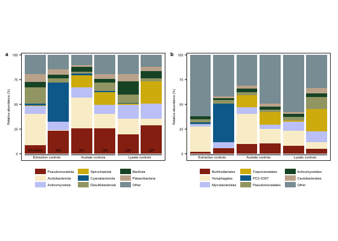

```r
p.phylum + p.order + plot_annotation(tag_levels = "a") &
  theme(
    plot.tag.location = "panel",
    plot.tag.position = c(-0.1, 0.99)
  )
```

**Expand code**

```r
remove(p.phylum, p.order)
```

**Expand code**

```r
ggsave(filename = "figures/controls.pdf", width = 180, height = 80, units = "mm")
```

# Network analysis ASV

**Expand code**

```r
cols.phylum <- c( # Sorted on abundance
  "Patescibacteria" = "#C7B19C",
  "Desulfobacterota" = "#A2A475",
  "Nanobdellota" = "#046C9A",
  "Omnitrophota" = "#00A08A",
  "Chloroflexota" = "#D69C4E",
  "Atribacterota" = "#972D15",
  "Bacillota" = "#FAEFD1",
  "Nitrospirota" = "#D8B70A",
  "Campylobacterota" = "#1B5331",
  "Bacteroidota" = "#899DA4"
)
s <- c(t0, unique(survey.amplicons$sample))

d <- seqtab %>%
  inner_join(tax, by = "seqid") %>%
  # Add the data from groundwaters at Äspö HRL
  rbind(survey.amplicons) %>%
  filter(phylum %in% names(cols.phylum)) %>%
  select(seqid.y = seqid, sample, relab.y = relab)

d <- seqtab %>%
  inner_join(tax, by = "seqid") %>%
  rbind(survey.amplicons) %>%
  filter(phylum %in% names(cols.phylum)) %>%
  select(seqid, sample, relab) %>%
  inner_join(d, by = "sample") %>%
  # Minimum read count of 0.05 %
  filter(sample %in% s & relab > 0.005)
```

**Expand code**

```r
cor <- tibble()

for (x in unique(d$seqid)) {
     n <- d %>%
       filter(seqid == x) %>%
       group_by(seqid.y) %>%
       summarise(spearman = cor(relab, relab.y, method = "spearman"), n = n()) %>%
       mutate(seqid = x) %>%
       mutate(type = "Groundwaters") %>%
       filter(!is.na(spearman) & n > 10 & spearman > 0)
     cor <- rbind(cor, n)
      }
```

**Expand code**

```r
s <- smd %>%
  filter(fraction == "non-fractionated") %>%
  pull(sample)

d <- seqtab %>%
  inner_join(tax, by = "seqid") %>%
  # Only use samples from non-fractionated cultures
  filter(phylum %in% names(cols.phylum) & sample %in% s) %>%
  select(seqid.y = seqid, sample, relab.y = relab)

# By running inner_join() on the samples, all combinations between seqid's are obtained
d <- seqtab %>%
  inner_join(tax, by = "seqid") %>%
  filter(phylum %in% names(cols.phylum) & sample %in% s) %>%
  select(seqid, sample, relab) %>%
  inner_join(d, by = "sample") %>%
  # Minimum read count of 0.1 %
  filter(sample %in% s & relab > 0.005)
```

**Expand code**

```r
for (x in unique(d$seqid)) {
     n <- d %>%
       filter(seqid == x) %>%
       group_by(seqid.y) %>%
       summarise(spearman = cor(relab, relab.y, method = "spearman"), n = n()) %>%
       mutate(seqid = x) %>%
       mutate(type = "Cultures") %>%
       # n > 10 implies at least ten co-occurrences
       filter(!is.na(spearman) & n > 3 & spearman > 0)
     cor <- rbind(cor, n)
      }
```

**Expand code**

```r
g <- cor %>% filter(spearman > 0.75) %>%
  filter(seqid != seqid.y) %>%
  rename(from = seqid, to = seqid.y) %>%
  select(from, to, n, spearman, type)

taxref <- survey.amplicons %>%
  filter(!seqid %in% tax$seqid) %>%
  select(-sample, -count, -relab) %>%
  rbind(tax) %>%
  distinct()

# 'a' for attributes
a <- g %>%
  select(type, from, to) %>%
  pivot_longer(-1, names_to = "relation", values_to = "seqid") %>%
  select(-relation) %>%
  left_join(taxref, by = "seqid") %>%
  select(seqid, phylum, type) %>%
  distinct(seqid, .keep_all = TRUE)

g <- igraph::graph_from_data_frame(g, directed = FALSE, vertices = a)
g <- tidygraph::as_tbl_graph(g)
```

**Expand code**

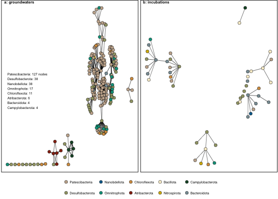

```r
library(ggraph)

t <- data.frame(x = 0, y = 6, type = "Groundwaters",
                label = "Patescibacteria: 127 nodes\nDesulfobacterota: 38\nNanobdellota: 38\nOmnitrophota: 17\nChloroflexota: 11\nAtribacterota: 6\nBacteroidota: 4\nCampylobacterota: 4")

l <- data.frame(x = rep(-Inf, 2), y = rep(Inf, 2), type = c("Groundwaters", "Cultures"),
                label = c("a: groundwaters", "b: incubations"))

g %>%
  tidygraph::activate(nodes) %>%
  mutate(group = as.factor(tidygraph::group_infomap())) %>%
  mutate(type = factor(type, levels = c("Groundwaters", "Cultures"))) %>%
  mutate(phylum = factor(phylum, levels = names(cols.phylum))) %>%
  ggraph(layout = 'stress') +
  geom_edge_fan(width = 0.2) +
  geom_node_point(aes(fill = phylum), shape = 21, stroke = 0.3, size = 2.4) +
  geom_text(data = t, aes(x = x, y = y, label = label), size = 6/.pt, hjust = 0) +
  geom_text(data = l, aes(x = x, y = y, label = label), size = 7/.pt, hjust = -0.1, fontface = "bold", vjust = 1.2) +
  facet_nodes(~type, scales = "free") +
  scale_fill_manual(values = cols.phylum) +
  theme_graph(
    base_family = "Helvetica",
    base_size = 5,
    plot_margin = margin(l = 1, r = 1)
    ) +
  theme(
    legend.title = element_blank(),
    legend.position = "bottom",
    panel.border = element_rect(fill = "transparent", linewidth = 0.75),
    legend.text = element_text(margin = margin(l = -2), size = 6),
    strip.text = element_blank()
    )
```

**Expand code**

```r
ggsave("figures/network.pdf", width = 180, height = 120, units = "mm")
```

# 16S data cultures

## NMDS initial experiment (Fig 3)

**Expand code**

```r
set.seed(999)

nmds <- seqtab %>% # Full size fraction
  inner_join(smd, by = "sample") %>%
  filter(!is.na(age) | sample %in% t0 & groundwater == "KR0015" | fraction == "control") %>%
  group_by(seqid) %>% filter(count > 2) %>% ungroup() %>%
  select(seqid, sample, count) %>% spread(seqid, count, fill = 0) %>%
  column_to_rownames("sample") %>% vegan::metaMDS()
```

```
Square root transformation
Wisconsin double standardization
*** Best solution was not repeated -- monoMDS stopping criteria:
    19: stress ratio > sratmax
     1: scale factor of the gradient < sfgrmin
```

**Expand code**

```r
vegan::scores(nmds)$sites %>%
  as.data.frame() %>%
  rownames_to_column("sample") %>%
  inner_join(smd, by = "sample") -> nmds.scores
```

**Expand code**

```r
i <- data.frame(x0 = -1,52, y0 = 0.5, 0.5)

cols.fraction <- c(
  "environmental" = "#FAEFD1",
  "fractionated" = "#A2A475",
  "non-fractionated" = "#1B5331",
  "control" = "#8D8680"
  )

p1 <- nmds.scores %>%
  mutate(medium = factor(medium, levels = c("ace","lys","env"))) %>%
  mutate(fraction = factor(fraction, levels =
                             c("environmental","fractionated","non-fractionated","control"))) %>%
  ggplot(aes(x = NMDS1, y = NMDS2,
             shape = medium,
             fill = fraction, color = fraction
             )
         ) +
  geom_vline(xintercept = 0, linetype = 'dotted') +
  geom_hline(yintercept = 0, linetype = 'dotted') +
  geom_point(size = 4.0, stroke = 0.7) +
  geom_text(data = nmds.scores,
            aes(label = age),
            size = 5/.pt, color = "black", na.rm = TRUE) +
  scale_shape_manual(values = c("ace" = 23, "lys" = 24, "env" = 21),
                     labels = c("Acetate", "Lysate", "Environmental")) +
  scale_color_manual(values = cols.fraction, labels = c("Environmental", "< 0.45 µm", "Non-fractionated", "Media control")) +
  scale_fill_manual(values = alpha(cols.fraction, alpha = 0.2), guide = "none") +
  annotate('text', x = -Inf, y = -Inf, size = 5/.pt, hjust = -0.1, vjust = -0.5,
           label = paste('Stress = ', round(nmds$stress, digits = 2))) +
  theme_tidy(legend = "bottom", fontsize = 5) +
  ggforce::geom_circle(aes(x0 = -1.54, y0 = 0.52, r = 0.45),
              data = i,
              inherit.aes = FALSE,
              fill = NA, color = "black", linewidth = 0.3, linetype = "dashed") +
  theme(
    aspect.ratio = 1.0,
    legend.title = element_blank(),
    legend.box = "vertical",
    legend.spacing.x = unit(0, "mm"),
    legend.box.margin = margin(),
    legend.margin = margin(),
    legend.text = element_text(margin = margin(l = 2, r = 8, unit = "pt")),
    legend.key.spacing.x = unit(0, "mm"),
    legend.key.size = unit(3, "mm")
    )
```

## Barplot KR0015 (Fig 3)

**Expand code**

```r
t <- seqtab %>%
  filter(sample %in% paste("P21015", seq(1042,1081), sep = "_")
           ) %>%
  inner_join(tax, by = "seqid") %>%
  group_by(phylum, sample) %>%
  # Sum the abundance of each phylum within a sample
  summarise(relab = sum(relab), .groups = 'drop_last') %>%
  # Calculate the mean abundance of each phylum over the categories
  summarise(mean_relab = sum(relab), .groups = 'drop') %>%
  filter(!is.na(phylum)) %>%
  top_n(9, mean_relab)

# The most abundant phyla, averaged over all cultures
t %>% arrange(desc(mean_relab))
```

```
# A tibble: 9 × 2
  phylum           mean_relab
  <chr>                 <dbl>
1 Pseudomonadota       10.8
2 Acidobacteriota       7.90
3 Spirochaetota         6.28
4 Patescibacteria       6.16
5 Desulfobacterota      3.22
6 Bacillota             1.54
7 Nanobdellota          0.967
8 Bacteroidota          0.874
9 Omnitrophota          0.853
```

**Expand code**

```r
t <- t %>% pull(phylum)

cols.phylum <- c(
  "Pseudomonadota" = "#972D15",
  "Acidobacteriota" = "#FAEFD1",
  "Spirochaetota" = "#D8B70A",
  "Patescibacteria" = "#C7B19C",
  "Desulfobacterota" = "#A2A475",
  "Bacillota" = "#1B5331",
  "Nanobdellota" = "#046C9A",
  "Bacteroidota" = "#D3D4D8",
  "Omnitrophota" = "#00A08A",
  "Other" = "#899DA4"
)
```

**Expand code**

```r
p2 <- seqtab %>%
  filter(sample %in% paste("P21015", seq(1042,1081), sep = "_")
           ) %>%
  inner_join(tax, by = "seqid") %>%
  mutate(phylum = case_when(
    phylum %in% t ~ phylum,
    is.na(phylum) ~ "Other",
    !phylum %in% t ~ "Other"
  )) %>%
  # Summarize in order to have the sum for each category and topphylum
  group_by(sample, phylum) %>%
  summarise(relab = sum(relab), .groups = 'drop') %>%
  inner_join(smd, by = "sample") %>%
  mutate(age = as.numeric(.$age)) %>%
  mutate(fraction = case_when(
    fraction == "non-fractionated" & medium == "ace" ~ "Acetate, non-fractionated",
    fraction == "non-fractionated" & medium == "lys" ~ "Lysate, non-fractionated",
    fraction == "fractionated" & medium == "ace" ~ "Acetate, < 0.45 µm fraction",
    fraction == "fractionated" & medium == "lys" ~ "Lysate, < 0.45 µm fraction"
  )) %>%
  mutate(phylum = factor(phylum, levels = rev(names(cols.phylum)))) %>%
  # Call the plot
  ggplot(aes(
    age,
    relab * 100,
    fill = phylum)) +
  geom_col() +
  scale_x_continuous(n.breaks = 10) +
  facet_wrap(~ fraction, nrow = 2) +
  labs(x = 'Week', y = 'Relative abundance (%)', fill = '') +
  scale_fill_manual(values = cols.phylum) +
  guides(fill = guide_legend(reverse = TRUE, nrow = 3)) +
  theme_tidy(legend = "bottom", fontsize = 5) +
  theme(
    aspect.ratio = 1.0,
    strip.background = element_blank(),
    legend.background = element_blank(),
    legend.key.height = unit(4, "mm"), legend.key.width = unit(3, "mm"),
    legend.text = element_text(margin = margin(l = 2)),
    legend.key.spacing.y = unit(0, "mm"),
    axis.ticks.x = element_blank(), axis.text.x = element_text(vjust = 2),
    legend.box.margin = margin(t = -5)
    )
```

**Expand code**

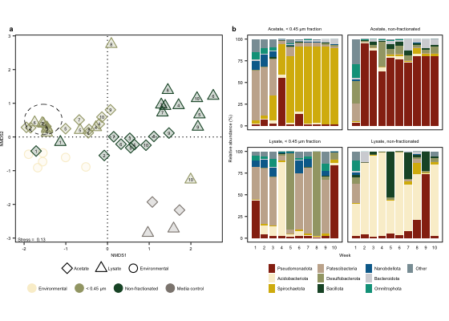

```r
p1 + p2 + plot_annotation(tag_levels = "a") & theme(
  plot.tag.location = "plot",
  plot.tag.position = c(0.05,0.98),
  plot.margin = margin(l = .1, r = .1),
  legend.box.margin = margin(t = -20)
)
```

**Expand code**

```r
ggsave("figures/fig-3.pdf", height = 11, width = 18, units = "cm")
```

## NMDS cultures three groundwaters (Fig S3)

**Expand code**

```r
set.seed(999)

nmds <- seqtab %>% # Full size fraction
  inner_join(smd, by = "sample") %>%
  filter(is.na(age) & groundwater == "KR0015") %>%
  group_by(seqid) %>% filter(count > 2) %>% ungroup() %>%
  select(seqid, sample, count) %>% spread(seqid, count, fill = 0) %>%
  column_to_rownames("sample") %>% vegan::metaMDS()
```

```
Square root transformation
Wisconsin double standardization
*** Best solution repeated 9 times
```

**Expand code**

```r
vegan::scores(nmds)$sites %>%
  as.data.frame() %>%
  rownames_to_column("sample") %>%
  inner_join(smd, by = "sample") -> nmds.scores
```

Plot the ordination

**Expand code**

```r
p1 <- nmds.scores %>%
  mutate(medium = factor(medium, levels = c("ace","lys","env"))) %>%
  ggplot(aes(x = NMDS1, y = NMDS2,
             shape = medium,
             fill = fraction, color = fraction
             )
         ) +
  geom_vline(xintercept = 0, linetype = 'dotted') +
  geom_hline(yintercept = 0, linetype = 'dotted') +
  geom_point(size = 4.0, stroke = 0.75) +
  geom_text(data = nmds.scores,
            aes(label = age),
            size = 6/.pt, color = "black", na.rm = TRUE) +
  scale_shape_manual(values = c("ace" = 23, "lys" = 24, "env" = 21),
                     labels = c("Acetate", "Lysate", "Environmental")) +
  scale_color_manual(values = cols.fraction, labels = c("Environmental", "< 0.45 µm", "Non-fractionated")) +
  scale_fill_manual(values = alpha(cols.fraction, alpha = 0.2), guide = "none") +
  annotate('text', x = -Inf, y = -Inf, size = 6/.pt, hjust = -0.1, vjust = -0.5,
           label = paste('Stress = ', round(nmds$stress, digits = 2))) +
  theme_tidy(legend = "bottom", fontsize = 6) +
  theme(
    #axis.title.x = element_blank(),
    axis.title.y = element_blank(),
    legend.title = element_blank(),
    legend.box = "vertical",
    legend.spacing.x = unit(0, "mm"),
    legend.box.margin = margin(),
    legend.margin = margin(),
    legend.text = element_text(margin = margin(l = 2, r = 8, unit = "pt")),
    legend.key.spacing.x = unit(0, "mm")
    )
```

**Expand code**

```r
set.seed(999)

nmds <- seqtab %>% # Full size fraction
  inner_join(smd, by = "sample") %>%
  filter(is.na(age) & groundwater == "SA1420") %>%
  group_by(seqid) %>% filter(count > 2) %>% ungroup() %>%
  select(seqid, sample, count) %>% spread(seqid, count, fill = 0) %>%
  column_to_rownames("sample") %>% vegan::metaMDS()
```

```
Square root transformation
Wisconsin double standardization
*** Best solution repeated 4 times
```

**Expand code**

```r
vegan::scores(nmds)$sites %>%
  as.data.frame() %>%
  rownames_to_column("sample") %>%
  inner_join(smd, by = "sample") -> nmds.scores
```

**Expand code**

```r
p2 <- nmds.scores %>%
  mutate(medium = factor(medium, levels = c("ace","lys","env"))) %>%
  ggplot(aes(x = NMDS1, y = NMDS2,
             shape = medium,
             fill = fraction, color = fraction
             )
         ) +
  geom_vline(xintercept = 0, linetype = 'dotted') +
  geom_hline(yintercept = 0, linetype = 'dotted') +
  geom_point(size = 4.0, stroke = 0.75) +
  geom_text(data = nmds.scores,
            aes(label = age),
            size = 6/.pt, color = "black", na.rm = TRUE) +
  scale_shape_manual(values = c("ace" = 23, "lys" = 24, "env" = 21),
                     labels = c("Acetate", "Lysate", "Environmental")) +
  scale_color_manual(values = cols.fraction, labels = c("Environmental", "< 0.45 µm", "Non-fractionated")) +
  scale_fill_manual(values = alpha(cols.fraction, alpha = 0.2), guide = "none") +
  annotate('text', x = -Inf, y = -Inf, size = 6/.pt, hjust = -0.1, vjust = -0.5,
           label = paste('Stress = ', round(nmds$stress, digits = 2))) +
  theme_tidy(legend = "bottom", fontsize = 6) +
  theme(
    axis.title.y = element_blank(),
    legend.title = element_blank(),
    legend.box = "vertical",
    legend.spacing.x = unit(0, "mm"),
    legend.box.margin = margin(),
    legend.margin = margin(),
    legend.text = element_text(margin = margin(l = 2, r = 8, unit = "pt")),
    legend.key.spacing.x = unit(0, "mm")
    )
```

**Expand code**

```r
set.seed(999)

nmds <- seqtab %>% # Full size fraction
  inner_join(smd, by = "sample") %>%
  filter(is.na(age) & groundwater == "SA2600") %>%
  group_by(seqid) %>% filter(count > 2) %>% ungroup() %>%
  select(seqid, sample, count) %>% spread(seqid, count, fill = 0) %>%
  column_to_rownames("sample") %>% vegan::metaMDS()
```

```
Square root transformation
Wisconsin double standardization
*** Best solution repeated 3 times
```

**Expand code**

```r
vegan::scores(nmds)$sites %>%
  as.data.frame() %>%
  rownames_to_column("sample") %>%
  inner_join(smd, by = "sample") -> nmds.scores
```

**Expand code**

```r
p3 <- nmds.scores %>%
  mutate(medium = factor(medium, levels = c("ace","lys","env"))) %>%
  ggplot(aes(x = NMDS1, y = NMDS2,
             shape = medium,
             fill = fraction, color = fraction
             )
         ) +
  geom_vline(xintercept = 0, linetype = 'dotted') +
  geom_hline(yintercept = 0, linetype = 'dotted') +
  geom_point(size = 4.0, stroke = 0.75) +
  geom_text(data = nmds.scores,
            aes(label = age),
            size = 6/.pt, color = "black", na.rm = TRUE) +
  scale_shape_manual(values = c("ace" = 23, "lys" = 24, "env" = 21),
                     labels = c("Acetate", "Lysate", "Environmental"), guide = "none") +
  scale_color_manual(values = cols.fraction, labels = c("Environmental", "< 0.45 µm", "Non-fractionated"), guide = "none") +
  scale_fill_manual(values = alpha(cols.fraction, alpha = 0.2), guide = "none") +
  annotate('text', x = -Inf, y = -Inf, size = 6/.pt, hjust = -0.1, vjust = -0.5,
           label = paste('Stress = ', round(nmds$stress, digits = 2))) +
  theme_tidy(legend = "bottom", fontsize = 6) +
  theme(
    axis.title.y = element_blank()
  )
```

**Expand code**

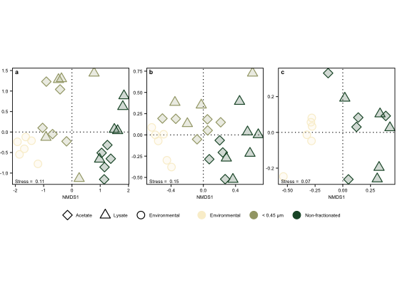

```r
p1 + p2 + p3 + plot_layout(nrow = 1, guides = "collect") + plot_annotation(tag_levels = "a") & theme(
  legend.position = "bottom",
  aspect.ratio = 1.0,
  plot.tag.location = "panel",
  plot.tag.position = c(0.04, 0.97),
  plot.margin = margin(t = 3, r = 3),
  panel.border = element_rect(fill = "transparent", linewidth = 0.75)
)
```

**Expand code**

```r
ggsave("figures/fig-s3.pdf", height = 90, width = 180, units = "mm")
```

## QPCR KR0015 (Fig 2)

**Expand code**

```r
qpcr <- read_tsv('data/qpcr.tsv', col_types = cols(.default = col_character(),
                                      quantity = col_double(),
                                      age = col_factor(levels = seq(1:10) %>% as.character())
                                      )
         ) %>% mutate(medium = gsub("ace","srm", medium)) %>%
  rename(kingdom = Kingdom)
```

**Expand code**

```r
p1 <- qpcr %>%
  group_by(sample, kingdom) %>%
  summarise(mean = mean(quantity), sd = 2 * sd(quantity), .groups = 'drop') %>%
  inner_join(smd, by = "sample") %>%
  mutate(category = paste(medium, fraction)) %>%
  # Call plot
  ggplot(aes(x = fct_relevel(age, seq(1:10) %>% as.character),
             y = mean,
             group = category,
             fill = fraction
             )
         ) +
  geom_line(aes(linetype = medium)) +
  facet_wrap(~ factor(kingdom, levels = c("Bacteria", "Archaea"))) +
  geom_pointrange(aes(ymin = mean - sd,
                      ymax = mean + sd),
                  size = 2, shape = 21, stroke = 0.5, fatten = 1) +
  labs(x = 'Week', y = expression("Gene copy number (mL"^"-1"*")")) +
  scale_y_log10(breaks = c(1e3,1e4,1e5,1e6,1e7),
                labels = c(expression("10"^"3"),
                           expression("10"^"4"),
                           expression("10"^"5"),
                           expression("10"^"6"),
                           expression("10"^"7")
                           )
                ) +
  scale_linetype(name = "Medium:", labels = c("Acetate", "Cell lysate"), guide = "none") +
  scale_fill_manual(values = cols.fraction,
                    labels = c("< 0.45 µm fraction", "Non-fractionated"),
                    name = "", guide = "none") +
  theme_tidy(legend = "right") +
  theme(
    plot.margin = margin(),
    legend.text = element_text(margin = margin(l = 0)),
    axis.ticks.length = unit(0.5, "mm"),
    panel.border = element_rect(fill = "transparent", linewidth = 0.75),
    legend.box.margin = margin(-8),
    )
```

## Microscopy (Fig 2)

**Expand code**

```r
growth <- read_tsv("data/micro_cultures.tsv", col_types = cols(.default = col_character(),
                                                  count = col_integer(),
                                                  date = col_date(format = "%d-%m-%Y"))
                   ) %>%
  mutate(week = case_when(
    date == "2021-10-15" ~  1,
    date == "2021-11-11" ~  5,
    date == "2021-11-25" ~  7,
    date == "2021-12-09" ~  9,
    date == "2021-12-30" ~ 12,
    date == "2022-01-18" ~ 15,
    date == "2022-02-03" ~ 17
  )) %>%
  filter(!sample %in% c("P26201_1051","P26201_1024")) %>%
  mutate(label = case_when(
    groundwater == "KR0015" ~  "Meteoric",
    groundwater == "SA1420" ~  "Marine",
    groundwater == "SA2600" ~  "Saline"
  ))

counts <- tibble(
  label = c("Meteoric","Marine","Saline"),
  min = c(680220, 59220, 14100),
  max = c(890910, 73910, 23000)
  )
```

**Expand code**

```r
# Microscopy counts on KR0015 groundwater in duplicates, obtaining 680,220 and 890,910 cells ml-1.
# Microscopy counts on SA1420 groundwater in duplicates, obtaining 59220 and 73910 cells ml-1.
# For SA2600, this number was 14,100 and 23,000 cells ml-1

p2 <- growth %>%
  ggplot(aes(x = week, y = count, fill = fraction)) +
  geom_rect(data = counts, aes(xmin = 1, xmax = 17, ymin = min, ymax = max), fill = "#8D8680", alpha = 0.5, inherit.aes = FALSE) +
  geom_line(aes(linetype = medium)) +
  geom_point(aes(fill = fraction), shape = 21, stroke = 0.5, size = 2) +
  scale_y_log10(limits = c(1e4,1e8),
                breaks = c(1e4,1e5,1e6,1e7),
                labels = c(expression("10"^"4"),
                           expression("10"^"5"),
                           expression("10"^"6"),
                           expression("10"^"7"))
                ) +
  scale_x_continuous(breaks = c(1,5,7,9,12,15,17),
                     labels = c("1", "5", "", "9", "12", "", "17")) +
  scale_fill_manual(values = cols.fraction,
                    labels = c("< 0.45 µm fraction", "Non-fractionated"),
                    name = "") +
  scale_linetype(name = "Medium:", labels = c("Acetate", "Cell lysate")) +
  facet_wrap(~ factor(label, levels = c("Meteoric", "Marine", "Saline")), ncol = 3) +
  labs(x = "Week", y = expression("Cell number (mL"^"-1"*")"), colour = "Fraction:") +
  theme_tidy(legend = "bottom") +
  theme(
    legend.margin = margin(t = -10, l = 20),
    plot.margin = margin(),
    panel.border = element_rect(fill = "transparent", linewidth = 0.5)
    )
```

**Expand code**

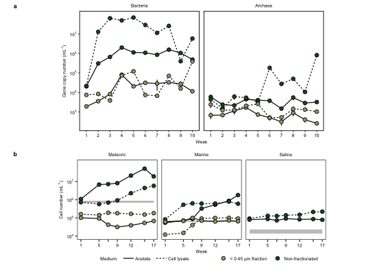

```r
p1 + p2 + plot_layout(nrow = 2, heights = c(3,2), guides = "collect") + plot_annotation(tag_levels = "a") & theme(
  aspect.ratio = 1.0,
  plot.margin = margin(b = 6),
  legend.position = "bottom",
  plot.tag.location = "plot",
  plot.tag.position = c(0.04, 0.96),
  legend.box.margin = margin(t = -4),
  legend.text = element_text(margin = margin(l = 0))
  )
```

**Expand code**

```r
ggsave(filename = "figures/fig-2.pdf", width = 14, height = 14, units = "cm")
```

## Barplot KR0015 - SA1420 - SA2600

**Expand code**

```r
t <- seqtab %>%
  inner_join(smd, by = "sample") %>% filter(groundwater == "KR0015") %>%
  filter(grepl("P26", sample)) %>%
  inner_join(tax, by = "seqid") %>%
  group_by(phylum, sample) %>%
  # Sum the abundance of each phylum within a sample
  summarise(relab = sum(relab), .groups = 'drop_last') %>%
  # Calculate the mean abundance of each phylum over the categories
  summarise(mean_relab = sum(relab), .groups = 'drop') %>%
  top_n(8, mean_relab) %>% arrange(desc(mean_relab)) %>% pull(phylum)
```

**Expand code**

```r
cols.phylum <- c(
  "Pseudomonadota" = "#972D15",
  "Bacillota" = "#1B5331",
  "Bacteroidota" = "#D3D4D8",
  "Desulfobacterota" = "#A2A475",
  "Patescibacteria" = "#C7B19C",
  "Omnitrophota" = "#00A08A",
  "Spirochaetota" = "#D8B70A",
  "Campylobacterota" = "#79402E",
  "Acidobacteriota" = "#FAEFD1",
  "Nanobdellota" = "#046C9A",
  "Actinomycetota" = "#C6CDF7",
  "Verrucomicrobiota" = "#D69C4E",
  "Other" = "#899DA4"
)
```

**Expand code**

```r
p1 <- seqtab %>%
  filter(grepl("P26", sample)) %>%
  inner_join(tax, by = "seqid") %>%
  mutate(phylum = if_else(phylum %in% t, phylum, "Other")) %>%
  # Summarize in order to have the sum for each category and topphylum
  group_by(sample, phylum) %>%
  summarise(relab = sum(relab), .groups = 'drop') %>%
  inner_join(smd, by = "sample") %>% filter(groundwater == "KR0015") %>%
  mutate(phylum = factor(phylum, levels = names(rev(cols.phylum)))) %>%
  mutate(fraction = case_when(
    fraction == "fractionated" & medium == "lys" ~ "Fractionated: lysate",
    fraction == "fractionated" & medium == "ace" ~ "Fractionated: acetate",
    fraction == "non-fractionated" & medium == "lys" ~ "Non-fractionated: lysate",
    fraction == "non-fractionated" & medium == "ace" ~ "Non-fractionated: acetate",
  )) %>%
   # Call the plot
  ggplot(aes(
    sample,
    relab * 100,
    fill = phylum)) +
  geom_col(show.legend = TRUE) +
  facet_wrap(~ fraction, scales = "free_x", nrow = 1) +
  labs(x = "", y = 'Relative abundance (%)', fill = '') +
  scale_fill_manual(values = cols.phylum, drop = FALSE) +
  theme_tidy(legend = "bottom") + guides(fill = guide_legend(nrow = 3, reverse = TRUE)) +
  theme(
    axis.text.x = element_blank(),
    axis.ticks.x = element_blank(),
    legend.key.width = unit(3.5, "mm"),
    legend.text = element_text(margin = margin(l = 2)),
    legend.margin = margin(t = -10)
  )
```

**Expand code**

```r
t <- seqtab %>%
  inner_join(smd, by = "sample") %>% filter(groundwater == "SA1420") %>%
  filter(grepl("P26", sample)) %>%
  inner_join(tax, by = "seqid") %>%
  group_by(phylum, sample) %>%
  # Sum the abundance of each phylum within a sample
  summarise(relab = sum(relab), .groups = 'drop_last') %>%
  # Calculate the mean abundance of each phylum over the categories
  summarise(mean_relab = sum(relab), .groups = 'drop') %>%
  top_n(8, mean_relab) %>% arrange(desc(mean_relab)) %>% pull(phylum)
```

**Expand code**

```r
p2 <- seqtab %>%
  filter(grepl("P26", sample)) %>%
  inner_join(tax, by = "seqid") %>%
  mutate(phylum = if_else(phylum %in% t, phylum, "Other")) %>%
  # Summarize in order to have the sum for each category and topphylum
  group_by(sample, phylum) %>%
  summarise(relab = sum(relab), .groups = 'drop') %>%
  inner_join(smd, by = "sample") %>% filter(groundwater == "SA1420") %>%
  mutate(phylum = factor(phylum, levels = names(rev(cols.phylum)))) %>%
  mutate(fraction = case_when(
    fraction == "fractionated" & medium == "lys" ~ "Fractionated: lysate",
    fraction == "fractionated" & medium == "ace" ~ "Fractionated: acetate",
    fraction == "non-fractionated" & medium == "lys" ~ "Non-fractionated: lysate",
    fraction == "non-fractionated" & medium == "ace" ~ "Non-fractionated: acetate",
  )) %>%
   # Call the plot
  ggplot(aes(
    sample,
    relab * 100,
    fill = phylum)) +
  geom_col(show.legend = TRUE) +
  facet_wrap(~ fraction, scales = "free_x", nrow = 1) +
  labs(x = "", y = 'Relative abundance (%)', fill = '') +
  scale_fill_manual(values = cols.phylum, drop = FALSE) +
  theme_tidy(legend = "bottom") + guides(fill = guide_legend(nrow = 3, reverse = TRUE)) +
  theme(
    axis.text.x = element_blank(),
    axis.ticks.x = element_blank(),
    legend.key.width = unit(3.5, "mm"),
    legend.text = element_text(margin = margin(l = 2)),
    legend.margin = margin(t = -10)
  )
```

**Expand code**

```r
t <- seqtab %>%
  inner_join(smd, by = "sample") %>% filter(groundwater == "SA2600") %>%
  filter(grepl("P26", sample)) %>%
  inner_join(tax, by = "seqid") %>%
  group_by(phylum, sample) %>%
  # Sum the abundance of each phylum within a sample
  summarise(relab = sum(relab), .groups = 'drop_last') %>%
  # Calculate the mean abundance of each phylum over the categories
  summarise(mean_relab = sum(relab), .groups = 'drop') %>%
  top_n(8, mean_relab) %>% arrange(desc(mean_relab)) %>% pull(phylum)
```

**Expand code**

```r
p3 <- seqtab %>%
  filter(grepl("P26", sample)) %>%
  inner_join(tax, by = "seqid") %>%
  mutate(phylum = if_else(phylum %in% t, phylum, "Other")) %>%
  # Summarize in order to have the sum for each category and topphylum
  group_by(sample, phylum) %>%
  summarise(relab = sum(relab), .groups = 'drop') %>%
  inner_join(smd, by = "sample") %>% filter(groundwater == "SA2600") %>%
  mutate(phylum = factor(phylum, levels = names(rev(cols.phylum)))) %>%
  mutate(fraction = case_when(
    fraction == "fractionated" & medium == "lys" ~ "Fractionated: lysate",
    fraction == "fractionated" & medium == "ace" ~ "Fractionated: acetate",
    fraction == "non-fractionated" & medium == "lys" ~ "Non-fractionated: lysate",
    fraction == "non-fractionated" & medium == "ace" ~ "Non-fractionated: acetate",
  )) %>%
   # Call the plot
  ggplot(aes(
    sample,
    relab * 100,
    fill = phylum)) +
  geom_col(show.legend = TRUE) +
  facet_wrap(~ fraction, scales = "free_x", nrow = 1) +
  labs(x = "", y = 'Relative abundance (%)', fill = '') +
  scale_fill_manual(values = cols.phylum, drop = FALSE) +
  theme_tidy(legend = "bottom") + guides(fill = guide_legend(nrow = 3, reverse = TRUE)) +
  theme(
    axis.text.x = element_blank(),
    axis.ticks.x = element_blank(),
    legend.key.width = unit(3.5, "mm"),
    legend.text = element_text(margin = margin(l = 2)),
    legend.margin = margin(t = -10)
  )
```

**Expand code**

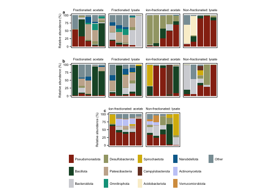

```r
p1 + p2 + p3 + plot_layout(nrow = 3, ncol = 1, guides = "collect", widths = c(2,2,1)) +
  plot_annotation(tag_levels = "a") & theme(
  axis.ticks.x = element_blank(),
  axis.text.x = element_blank(),
  axis.title.x = element_blank(),
  plot.tag.location = "panel",
  plot.tag.position = c(-0.05, 1.06),
  legend.position = "bottom",
  legend.box.margin = margin(t = 10),
  aspect.ratio = 1
)
```

**Expand code**

```r
ggsave(filename = "figures/fig-s4.pdf", width = 180, height = 180, units = "mm")
```

**Expand code**

```r
for (d in 1:50) {
  i[d, "n"] <- sample(x, 1)
}
```

# Genome-resolved metagenomics

## Basic stats on the MAGs

**Expand code**

```r
cols.phylum <- c(
  "Desulfobacterota" = "#A2A475",
  "Pseudomonadota" = "#972D15",
  "Bacillota" = "#1B5331",
  "Patescibacteria" = "#C7B19C",
  "Nanobdellota" = "#046C9A",
  "Chloroflexota" = "#D69C4E",
  "Spirochaetota" = "#D8B70A",
  "Campylobacterota" = "#FAEFD1",
  "Iainarchaeota" = "#00A08A",
  "Other" = "#899DA4"
)

t <- c("Bacillota","Desulfobacterota","Pseudomonadota","Patescibacteria","Nanobdellota","Other")
t <- names(cols.phylum)

# Prepare data for plot
i <- quality %>%
  inner_join(bintax, by = "genome") %>%
  mutate(phylum = ifelse(phylum %in% t, phylum, "Other")) %>%
  mutate(phylum = factor(phylum, levels = t)) %>%
  select(genome, phylum, completeness, gc_content, genome_size, coding_density) %>%
  distinct() %>%
  mutate(genome.size = genome_size / 1e6)
```

**Expand code**

```r
lm(gc_content ~ genome_size, data = quality) %>% summary()
```

```
Call:
lm(formula = gc_content ~ genome_size, data = quality)

Residuals:
     Min       1Q   Median       3Q      Max
-0.15655 -0.06232 -0.02604  0.07979  0.13851

Coefficients:
             Estimate Std. Error t value Pr(>|t|)
(Intercept) 3.058e-01  3.670e-02   8.332 1.26e-09 ***
genome_size 5.080e-08  1.029e-08   4.935 2.23e-05 ***
---
Signif. codes:  0 '***' 0.001 '**' 0.01 '*' 0.05 '.' 0.1 ' ' 1

Residual standard error: 0.09515 on 33 degrees of freedom
Multiple R-squared:  0.4246,    Adjusted R-squared:  0.4072
F-statistic: 24.36 on 1 and 33 DF,  p-value: 2.233e-05
```

**Expand code**

```r
p1 <- i %>%
  ggplot(aes(
    genome.size,
    gc_content,
    color = phylum,
    fill = phylum
    )) +
  geom_smooth(method = "lm", formula = y ~ x, colour = "black", fill = "#d9d9d9", se = TRUE, linewidth = 0.4) +
  geom_point(size = 3, shape = 21, stroke = 0.5, key_glyph = "rect") +
  labs(x = "Estimated genome size (Mb)", y = "Estimated GC content (%)", color = "") +
  scale_colour_manual(values = cols.phylum, guide = "none") +
  scale_fill_manual(values = alpha(cols.phylum, alpha = 0.5)) +
  theme_tidy(fontsize = 6) +
  scale_x_continuous(breaks = c(1,2,3,4,5,6)) +
  annotate("text", x = Inf, y = -Inf,
           label = "paste(R ^ 2, \" = 0.41\")",
           size = 6/.pt, vjust = -0.5, hjust = 1, parse = TRUE) +
  theme(
    axis.line = element_line(),
    panel.border = element_blank()
  )
```

**Expand code**

```r
p2 <- i %>%
  mutate(phylum = case_when(
    phylum %in% c("Nanobdellota", "Patescibacteria", "Bacillota", "Desulfobacterota", "Pseudomonadota") ~ phylum,
    .default = "Other"
  )) %>%
  mutate(phylum = factor(phylum, levels = c(
    "Nanobdellota", "Patescibacteria", "Other", "Bacillota", "Desulfobacterota", "Pseudomonadota"
  ))) %>%
  ggplot(aes(
    phylum,
    completeness,
    group = phylum,
    fill = phylum,
    color = phylum
    )) +
  geom_boxplot(linewidth = 0.5, outlier.colour = "white") +
  geom_jitter(width = 0.2, size = 2, shape = 21, stroke = 0.5) +
  labs(x = "", y = "Estimated completeness (%)", fill = "") +
  scale_fill_manual(values = alpha(cols.phylum, alpha = 0.5), guide = "none") +
  scale_color_manual(values = cols.phylum, guide = "none") +
  theme_tidy(legend = "bottom", fontsize = 6) +
  theme(
    axis.line = element_line(),
    panel.border = element_blank(),
    axis.text.x = element_blank(),
    axis.ticks.x = element_blank(),
    axis.title.y = element_text(margin = margin()),
    plot.margin = margin()
  )
```

**Expand code**

```r
lm(coding_density ~ genome_size, data = quality) %>% summary()
```

```
Call:
lm(formula = coding_density ~ genome_size, data = quality)

Residuals:
     Min       1Q   Median       3Q      Max
-0.05556 -0.01303 -0.00046  0.01275  0.03787

Coefficients:
              Estimate Std. Error t value Pr(>|t|)
(Intercept)  9.172e-01  8.112e-03 113.064  < 2e-16 ***
genome_size -6.991e-09  2.275e-09  -3.072  0.00424 **
---
Signif. codes:  0 '***' 0.001 '**' 0.01 '*' 0.05 '.' 0.1 ' ' 1

Residual standard error: 0.02103 on 33 degrees of freedom
Multiple R-squared:  0.2224,    Adjusted R-squared:  0.1989
F-statistic: 9.439 on 1 and 33 DF,  p-value: 0.004236
```

**Expand code**

```r
p3 <- i %>%
  ggplot(aes(
    genome.size,
    coding_density,
    color = phylum,
    fill = phylum
    )) +
  geom_smooth(method = "lm", formula = y ~ x, colour = "black", fill = "#d9d9d9", se = TRUE, linewidth = 0.4) +
  geom_point(size = 3, shape = 21, stroke = 0.5) +
  labs(x = "Estimated genome size (Mb)", y = "Estimated coding density", color = "") +
  scale_colour_manual(values = cols.phylum, guide = "none") +
  scale_fill_manual(values = alpha(cols.phylum, alpha = 0.5), guide = "none") +
  theme_tidy(fontsize = 6) +
  scale_x_continuous(breaks = c(1,2,3,4,5,6)) +
  scale_y_continuous(n.breaks = 7) +
  annotate("text", x = 6, y = 0.93,
           label = "paste(R ^ 2, \" = 0.20\")",
           size = 6/.pt, vjust = 1, hjust = 1, parse = TRUE) +
  theme(
    axis.line = element_line(),
    panel.border = element_blank()
  )
```

**Expand code**

```r
nmds <- coverm %>%
  # Sum the abundance of both coverage per metagenome
  mutate(abundance = 1) %>%
  inner_join(emapper, by = "genome", relationship = "many-to-many") %>%
  # Filter out NA and add multiple KOs on new line
  separate_rows(ko, sep = ",") %>%
  # Sum the abundance of each KO within the metagenomes
  group_by(genome, ko) %>%
  summarise(abundance = sum(abundance), .groups = "drop") %>%
  # Pivot to prepare a numerical matrix
  pivot_wider(names_from = "ko", values_from = "abundance", values_fill = 0) %>%
  column_to_rownames("genome") %>%
  vegan::metaMDS()
```

```
Square root transformation
Wisconsin double standardization
*** Best solution was not repeated -- monoMDS stopping criteria:
     2: no. of iterations >= maxit
    18: stress ratio > sratmax
```

**Expand code**

```r
nmds.scores <- vegan::scores(nmds)$sites %>%
  as.data.frame() %>%
  rownames_to_column("genome")
```

**Expand code**

```r
p4 <- nmds.scores %>%
  inner_join(bintax, by = "genome") %>%
  mutate(phylum = ifelse(phylum %in% t, phylum, "Other")) %>%
  # Plot
  ggplot(aes(x = NMDS1 * -1,
             y = NMDS2,
             colour = fct_relevel(phylum,t),
             fill = phylum
             )) +
  geom_vline(xintercept = 0, linetype = 'dotted', linewidth = 0.5) +
  geom_hline(yintercept = 0, linetype = 'dotted', linewidth = 0.5) +
  # Points for samples, coloured by nature
  geom_point(size = 3, shape = 21, stroke = 0.5) +
  theme_tidy(fontsize = 6) + labs(x = "NMDS1", y = "NMDS2") +
  scale_color_manual(values = cols.phylum, name = "Phylum", guide = "none") +
  scale_fill_manual(values = alpha(cols.phylum, alpha = 0.5), name = "", guide = "none") +
  scale_y_continuous(breaks = c(-0.5, 0, 0.5)) +
  annotate('text', x = -Inf, y = -Inf, size = 6/.pt,
           label = paste('Stress = ', round(nmds$stress, digits = 2)),
           hjust = -0.1, vjust = -0.5) +
  theme(
    panel.border = element_rect(fill = "transparent", linewidth = 0.75),
    axis.title.y = element_text(margin = margin()),
    legend.spacing.x = unit(-0.5, "mm")
    )
```

**Expand code**

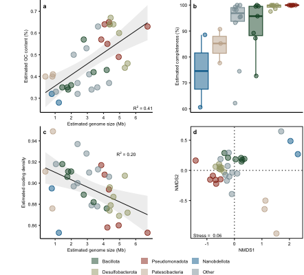

```r
p1 + p2 + p3 + p4 + plot_layout(guides = "collect", nrow = 2) & plot_annotation(tag_levels = c("a", "b", "c", "d")) &
  theme(
    aspect.ratio = 1.0,
    plot.margin = margin(r = 1),
    plot.tag.location = "panel",
    plot.tag.position = c(0.04, 0.95),
    legend.position = "bottom",
    axis.ticks.length = unit(".75", "mm"),
    legend.margin = margin(t = -4),
    legend.text = element_text(hjust = 0),
    legend.key.size = unit("3", "mm"),
    legend.title = element_blank()
    )
```

**Expand code**

```r
ggsave(filename = "figures/fig-4.pdf", width = 12, height = 12, units = "cm")
```

## KO mapper

**Expand code**

```r
km <- data.frame()
for (file in list.files("data/kmapper/", full.names = TRUE)) {
  genome <- substr(file, 15, nchar(file)) %>% gsub(".txt", "", .)
  i <- read_tsv(file, col_names = FALSE, show_col_types = FALSE)
  i <- i %>% filter(grepl("M00", X1)) %>%
    mutate(genome = genome) %>%
    mutate(module = substr(X1, 1, 6)) %>%
    mutate(completeness = sub(".*\\s", "", X1)) %>%
    mutate(completeness = gsub(")", "", completeness)) %>%
    select(-X1)
  km <- km %>% rbind(i)
}

km <- km %>%
  mutate(genes = gsub("/.*", "", completeness) %>% as.numeric()) %>%
  mutate(total = gsub(".*/", "", completeness) %>% as.numeric()) %>%
  mutate(score = case_when(
    genes == total ~ "c",
    (total - genes) == 1 ~ "i",
    .default = "m"
  )) %>%
  select(genome, module, score) %>%
  # Assign a value for every genome-module combination
  pivot_wider(names_from = "module", values_from = "score", values_fill = "m") %>%
  pivot_longer(-1, values_to = "score", names_to = "module")
```

**Expand code**

```r
km <- km %>% mutate(label = case_when(
    module == "M00001" ~ "M00001: Glycolysis",
    module == "M00002" ~ "M00002: Glycolysis core module",
    #module == "M00003" ~ "M00003: Gluconeogenesis",
    module == "M00307" ~ "M00307: Pyruvate oxidation",
    module == "M00008" ~ "M00008: Enter-Doudoroff pathway",
    module == "M00009" ~ "M00009: TCA cycle",
    module == "M00004" ~ "M00004: Pentose phosphate pathway (PPP)",
    module == "M00007" ~ "M00007: PPP, non-oxidative",
    module == "M00082" ~ "M00082: Fatty acids biosynthesis",
    #module == "M00549" ~ "M00549: UDP-Glc biosynthesis",
    #module == "M00909" ~ "M00909: UDP-GlcNAc biosynthesis",
    #module == "M00020" ~ "M00020: AA biosynthesis: serine",
    module == "M00016" ~ "M00016: AA biosynthesis: lysine",
    module == "M00021" ~ "M00021: AA biosynthesis: cysteine",
    module == "M00019" ~ "M00019: AA biosynthesis: valine/isoleucine",
    #module == "M00017" ~ "M00017: AA biosynthesis: methionine",
    #module == "M00048" ~ "M00048: De novo purine biosynthesis",
    module == "M00053" ~ "M00053: Deoxyribonucleotide biosynthesis",
    #module == "M00051" ~ "M00051: De novo pyrimidine biosynthesis",
    module == "M00052" ~ "M00052: Ribonucleotide biosynthesis",
    .default = NA
  ))

t <- tibble(
  x = c(0.5, 7.55, 13.55, 20.55, 23.55, 25.55, 26.55, 27.55, 28.55),
  xend = c(7.45, 13.45, 20.45, 23.45, 25.45, 26.45, 27.45, 28.45, 29.45),
  y = rep(14.3, 9),
  yend = rep(14.3, 9),
  phylum = c("Desulfobacterota","Pseudomonadota","Bacillota","Patescibacteria","Nanobdellota",
             "Chloroflexota","Spirochaetota","Campylobacterota","Iainarchaeota")
  ) %>%
  mutate(phylum = factor(phylum, names(cols.phylum)))

cols.phylum <- c(
  "Desulfobacterota" = "#A2A475",
  "Pseudomonadota" = "#972D15",
  "Bacillota" = "#1B5331",
  "Patescibacteria" = "#C7B19C",
  "Nanobdellota" = "#046C9A",
  "Chloroflexota" = "#D69C4E",
  "Spirochaetota" = "#D8B70A",
  "Campylobacterota" = "#FAEFD1",
  "Iainarchaeota" = "#00A08A"
)

name <- bintax %>%
  filter(genome %in% km$genome) %>%
  mutate(phylum = factor(phylum, levels = names(cols.phylum))) %>%
  arrange(phylum) %>%
  mutate(genus = case_match(genus, NA ~ family, .default = genus)) %>%
  mutate(taxon = if_else(is.na(species), paste(genus, "sp."), species)) %>%
  pull(taxon) %>% unique()
```

**Expand code**

```r
d <- quality %>% inner_join(bintax, by = "genome") %>%
  mutate(genus = case_match(genus, NA ~ family, .default = genus)) %>%
  mutate(taxon = if_else(is.na(species), paste(genus, "sp."), species)) %>%
  mutate(taxon = factor(taxon, levels = name)) %>% filter(!is.na(taxon)) %>%
  select(taxon, completeness) %>% arrange(taxon) %>%
  mutate(x = seq(1,29, by = 1)) %>%
  mutate(y = rep(13.8, 29))

p1 <- km %>%
  inner_join(bintax, by = "genome") %>%
  mutate(genus = case_match(genus, NA ~ family, .default = genus)) %>%
  mutate(taxon = if_else(is.na(species), paste(genus, "sp."), species)) %>%
  mutate(taxon = factor(taxon, levels = name)) %>%
  filter(!is.na(label)) %>%
  # Add genome completeness
  inner_join(quality, by = "genome") %>%
  ggplot(aes(
    x = taxon,
    y = fct_rev(label),
    fill = score
  )) +
  geom_tile(color = "white") +
  scale_x_discrete(position = "top") +
  scale_fill_manual(values = c("c" = "#707151",
                               "i" = "#B6B79B",
                               "m" = "#F0F1EB"),
                    label = c("c" = "Complete",
                              "i" = "One block missing",
                              "m" = "Incomplete or missing"),
                    name = "Module completeness:") +
  theme_tidy(fontsize = 5) + coord_fixed() +
  geom_text(data = d, aes(x = x, y = y, label = round(completeness, digits = 0)), inherit.aes = FALSE, size = 5/.pt) +
  geom_vline(xintercept =  7.5, linewidth = 0.6, color = "white") +
  geom_vline(xintercept = 13.5, linewidth = 0.6, color = "white") +
  geom_vline(xintercept = 20.5, linewidth = 0.6, color = "white") +
  geom_vline(xintercept = 23.5, linewidth = 0.6, color = "white") +
  geom_vline(xintercept = 25.5, linewidth = 0.6, color = "white") +
  geom_segment(data = t, aes(x = x, xend = xend, y = y, yend = yend, color = phylum), linewidth = 2, inherit.aes = FALSE) +
  scale_color_manual(values = cols.phylum, guide = "none") +
  theme(
    legend.position = "bottom",
    legend.key.height = unit(3, "mm"), legend.key.width = unit(2, "mm"),
    legend.text = element_text(margin = margin(l = 2)),
    legend.margin = margin(t = -10),
    axis.text.x.top = element_text(angle = 90, hjust = 0, vjust = 0.6, size = 5),
    axis.ticks = element_blank(),
    axis.title.x = element_blank(),
    axis.title.y = element_blank(),
    panel.border = element_blank()
  )
```

## Metabolic weight

**Expand code**

```r
# Two MAGs have no metabolic weight (i.e. are either low abundant or have low metabolic potential)
i <- list(
  genome = c("MEGAHIT-MaxBin2Refined-VK-3516-KFM02a-3_S40_L002.026", "MEGAHIT-MetaBAT2Refined-VK-3516-KFM02a-3_S40_L002.49_sub"),
  pathway = c("Fermentation", "Fermentation"),
  mw = c(0, 0))

mw <- read_tsv("data/metabolic.tsv.gz", show_col_types = FALSE) %>%
  select(-sample, -mw.function) %>%
  rbind(i) %>%
  group_by(genome, pathway) %>% summarise(mw = sum(mw), .groups = "drop") %>%
  pivot_wider(names_from = "pathway", values_from = "mw", values_fill = 0) %>%
  pivot_longer(-1, names_to = "pathway", values_to = "mw") %>%
  # Prepare the labels for the plot
  mutate(label = pathway) %>%
  mutate(label = gsub(".arbon", "C", label)) %>%
  mutate(label = gsub(" - ", ": ", label)) %>%
  mutate(label = gsub("amino acid", "AA", label)) %>%
  mutate(label = gsub(" pathway", "", label)) %>%
  mutate(label = gsub("\\|\\|vnfDKG\\|\\|", ", ", label)) %>%
  mutate(label = gsub(" degradation", "", label)) %>%
  mutate(label = gsub("methanol oxidation", "methanol", label)) %>%
  mutate(label = gsub("Iron oxidation:", "Iron oxidation", label)) %>%
  mutate(label = gsub("N2", "N", label))
```

**Expand code**

```r
d <- c(
  "Organic C oxidation: complex C",
  "Organic C oxidation: AA utilization",
  "Organic C oxidation: aromatics",
  #"Organic C oxidation: methanol",
  "Organic C oxidation: fatty acid",
  "C fixation: CBB cycle (Rubisco)",
  "C fixation: Reverse TCA cycle",
  "C fixation: 3HP/4HB",
  "C fixation: Wood-Ljungdahl",
  "Acetate oxidation",
  "Fermentation",
  #"Hydrogen generation",
  #"Hydrogen oxidation",
  "N fixation: nifDK, nifH",
  "Sulfur oxidation: sdo",
  "Sulfate reduction",
  "Sulfide oxidation: sqr"
  #"Iron oxidation",
  #"Iron reduction"
) %>% rev()
```

**Expand code**

```r
name <- bintax %>%
  filter(phylum %in% names(cols.phylum)) %>%
  mutate(phylum = factor(phylum, levels = names(cols.phylum))) %>%
  arrange(phylum) %>%
  mutate(genus = case_match(genus, NA ~ family, .default = genus)) %>%
  mutate(taxon = if_else(is.na(species), paste(genus, "sp."), species)) %>%
  pull(taxon) %>% unique()
```

**Expand code**

```r
t <- tibble(
  x = c(0.5, 7.55, 13.55, 20.55, 23.55, 25.55, 26.55, 27.55, 28.55),
  xend = c(7.45, 13.45, 20.45, 23.45, 25.45, 26.45, 27.45, 28.45, 29.45),
  y = rep(14.8, 9),
  yend = rep(14.8, 9),
  phylum = c("Desulfobacterota","Pseudomonadota","Bacillota","Patescibacteria","Nanobdellota",
             "Chloroflexota","Spirochaetota","Campylobacterota","Iainarchaeota")
  ) %>%
  mutate(phylum = factor(phylum, names(cols.phylum)))

p2 <- mw %>%
  inner_join(bintax, by = "genome") %>%
  mutate(genus = case_match(genus, NA ~ family, .default = genus)) %>%
  mutate(taxon = if_else(is.na(species), paste(genus, "sp."), species)) %>%
  # Order the genomes
  filter(taxon %in% name) %>%
  mutate(taxon = factor(taxon, name)) %>%
  # Order the pathways
  filter(label %in% d) %>%
  mutate(label = factor(label, d)) %>%
  mutate(score = if_else(mw > 0, "c", "m")) %>%
  # Plot
  ggplot(aes(
    x = taxon,
    y = label,
    fill = score
    )) +
  geom_tile(color = "white") +
  scale_fill_manual(
    values = c("c" = "#707151", "m" = "#F0F1EB"),
    label = c("c" = "Present", "m" = "Absent"),
    guide = "none") +
  theme_tidy(fontsize = 5) + coord_fixed() +
  geom_vline(xintercept =  7.5, linewidth = 0.6, color = "white") +
  geom_vline(xintercept = 13.5, linewidth = 0.6, color = "white") +
  geom_vline(xintercept = 20.5, linewidth = 0.6, color = "white") +
  geom_vline(xintercept = 23.5, linewidth = 0.6, color = "white") +
  geom_vline(xintercept = 25.5, linewidth = 0.6, color = "white") +
  geom_segment(data = t, aes(x = x, xend = xend, y = y, yend = yend, color = phylum), linewidth = 2, inherit.aes = FALSE) +
  scale_color_manual(values = cols.phylum) +
  theme(
    axis.title.x = element_blank(),
    axis.title.y = element_blank(),
    legend.position = "right",
    legend.title = element_blank(),
    legend.spacing.x = unit(0, "mm"),
    legend.box.margin = margin(),
    panel.border = element_blank(),
    axis.ticks = element_blank(),
    axis.text.x = element_blank(),
    legend.margin = margin(t = -10),
    legend.key.width = unit(4, "mm"),
    legend.key.height = unit(3, "mm"),
    legend.text = element_text(margin = margin(l = 2))
  )
```

## Aerobic respiration

**Expand code**

```r
i <- emapper %>% mutate(gene = case_when(
  grepl("1.6.5.3", ec) ~ "NADH:ubiquinone oxidoreductase",
  grepl("1.2.5.3", ec) ~ "Aerobic CO dehydrogenase",
  grepl("1.9.3.1", ec) ~ "Cytochrome c oxidase",
  grepl("3.6.3.14", ec) ~ "F-type H+/Na+-transporting ATPase",
  .default = "Other"
  )) %>%
  group_by(genome, gene) %>% summarise(n = n(), .groups = "drop") %>%
  pivot_wider(names_from = "gene", values_from = "n", values_fill = 0) %>%
  pivot_longer(-1, names_to = "gene", values_to = "n")
```

**Expand code**

```r
t <- tibble(
  x = c(0.5, 7.55, 13.55, 20.55, 23.55, 25.55, 26.55, 27.55, 28.55),
  xend = c(7.45, 13.45, 20.45, 23.45, 25.45, 26.45, 27.45, 28.45, 29.45),
  y = rep(4.8, 9),
  yend = rep(4.8, 9),
  phylum = c("Desulfobacterota","Pseudomonadota","Bacillota","Patescibacteria","Nanobdellota",
             "Chloroflexota","Spirochaetota","Campylobacterota","Iainarchaeota")
  ) %>%
  mutate(phylum = factor(phylum, names(cols.phylum)))

p3 <- i %>%
  inner_join(bintax, by = "genome") %>%
  mutate(genus = case_match(genus, NA ~ family, .default = genus)) %>%
  mutate(taxon = if_else(is.na(species), paste(genus, "sp."), species)) %>%
  # Order the genomes
  filter(taxon %in% name) %>%
  mutate(taxon = factor(taxon, name)) %>%
  mutate(n = if_else(n > 1, 1, n)) %>%
  mutate(n = as.character(n)) %>%
  filter(gene != "Other") %>%
  # Plot
  ggplot(aes(
    x = taxon,
    y = gene,
    fill = n
    )) +
  geom_tile(color = "white") +
  scale_fill_manual(values = c("1" = "#707151",
                               "0" = "#F0F1EB"),
                    label = c("1" = "Present",
                              "0" = "Absent")) +
  theme_tidy(fontsize = 5) + coord_fixed() + guides(fill = guide_legend(reverse = TRUE)) +
  geom_vline(xintercept =  7.5, linewidth = 0.6, color = "white") +
  geom_vline(xintercept = 13.5, linewidth = 0.6, color = "white") +
  geom_vline(xintercept = 20.5, linewidth = 0.6, color = "white") +
  geom_vline(xintercept = 23.5, linewidth = 0.6, color = "white") +
  geom_vline(xintercept = 25.5, linewidth = 0.6, color = "white") +
  geom_segment(data = t, aes(x = x, xend = xend, y = y, yend = yend, color = phylum), linewidth = 2, inherit.aes = FALSE) +
  scale_color_manual(values = cols.phylum, guide = "none") +
  theme(
    axis.title.x = element_blank(),
    axis.title.y = element_blank(),
    legend.position = "bottom",
    legend.title = element_blank(),
    legend.spacing.x = unit(0, "mm"),
    legend.box.margin = margin(),
    panel.border = element_blank(),
    axis.ticks = element_blank(),
    axis.text.x = element_blank(),
    legend.margin = margin(t = -10),
    legend.key.height = unit(3, "mm"), legend.key.width = unit(2, "mm"),
  )
```

**Expand code**

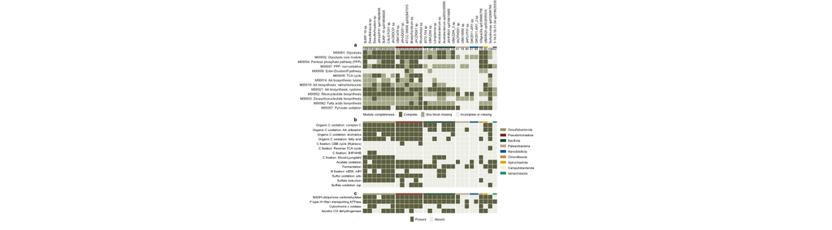

```r
p1 / p2 / p3 + plot_annotation(tag_levels = 'a') & theme(
  legend.box.margin = margin(l = -8),
  plot.margin = margin(b = 6),
  legend.text = element_text(margin = margin(l = 2)),
  plot.tag.location = 'panel',
  plot.tag.position = c(-0.05, 1.03),
  axis.text.y = element_text(size = 5, margin = margin(r = -1))
  )
```

**Expand code**

```r
ggsave("figures/fig-5.pdf", width = 180, height = 180, units = "mm")
```

# Supplementary table metagenomic assemblies